# Modular Programming

Lead Developer: Jonathon Mellor

## Learning Objectives

The aim of this course is for participants to:

- understand why code should be structured, and how modules help with this
- understand the important considerations when converting code into functions and modules
- be able to write code as functions and to import them
- consider how to group sets of functions into modules

### Target Audience

This course contains explanations and examples in both Python and R.

This course assumes basic programming knowledge in the participant’s preferred language. Having completed an introductory course or having experience in analysis would count.

This course shows how to structure code for analysis projects. It assumes the participant can already:

- work with data frames (load and manipulate)
- perform basic data analysis (summary statistics)
- write simple functions to perform tasks

# 1 Introduction

This course shows how to convert code into functions and modules. This gives code a better structure and as a result makes it reproducible and easier to maintain.

To do this we will go through a case study, where we re-structure existing code. During this we will highlight key concepts and considerations when designing code.

This course was created using existing guidance for programming for analysis in Government: [Quality Assurance of Code for Analysis and Research](https://best-practice-and-impact.github.io/qa-of-code-guidance/), which contains extensive guidance on how to perform reproducible analysis.

## 1.1 Why Structure Code?

> Well structured code is easier to read and easier to maintain.

Putting time into designing code well will payoff in the long run. Well structured code is important for reproducibility and effectiveness.

Writing programs quickly - without considering their design and structure - can cause significant headache and errors down the line.

You may come across Python and R files which do crucial work but are thousands of lines long without a clear order. These types of files and notebooks become difficult to understand as they get bigger. The less time spent scrolling through files looking for variables the better.

### 1.1.1 Components

Functions, modules and packages structure programs, making them:

- more readable
- easier to fix
- simpler to add new features to

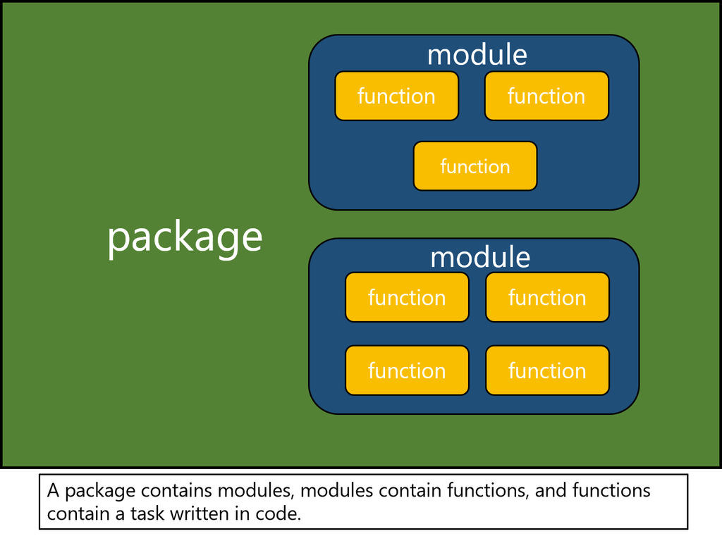

A module is a file that contains one or more units of code - in our case: functions. A collection of module files together forms a package.

You have already been using functions, modules and packages that were written by other people. For example, [`pandas`](https://pandas.pydata.org/) and [`dplyr`](https://dplyr.tidyverse.org/) are both packages which contain modules and functions.

You can use automated tests to check that each component of your code performs as expected.

Testing sections of your code independently using code - “Unit Testing” - is a concept covered in further courses. To do this your code needs to use functions, modules and packages.

For government analysts you can access the Unit Testing course [on the GSS Learning Hub](https://learninghub.ons.gov.uk/totara/catalog/index.php).

Testing multiple sections together and their interactions with each other is called - “Integration testing”.

To show how to structure code in an analysis context we will use an example scenario to go through the steps taken.

### Introducing the Case Study

You have been assigned to a group within your department responsible for analysing populations across the world. This work is in collaboration with the United Nations.

Your job is to provide analysis of population densities across the different United Nations Sustainable Development Goal (SDG) regions. You must provide average population density values for each SDG region.

One of your colleagues has already conducted this analysis on an *ad hoc* basis. They have given you their code to start with, but they have only analysed one year of data so far. You have been asked to write code that will be able to analyse multiple years of data, all in different files.

Before tackling the big task of analysing all the data, you are going to restructure your colleagues code. To make the process more reproducible in the future you will restructure their code into functions and modules.

This process is called “refactoring”.

Refactoring is a process of improving your code, while keeping it able to perform the same task. This helps clean the code and improve its design.

You have been sent two data sets needed to reproduce the analysis your colleague performed. Have a look through the data, what steps do you think need to be considered to make the data analysable?

#### Population Density

The `population_density_2019.csv` data contains each country’s population density, name and a unique country and parent group code column. There is also a year column.

The data is only from 2019.

| Country | Country and parent code | Population Density | Year |
| --- | --- | --- | --- |
| Burundi | CC108_PC108 | 4.490100e+02 | 2019 |
| Comoros | CC174_PC174 | 4.572225e+02 | 2019 |
| Djibouti | CC262_PC262 | 4.199987e+01 | 2019 |
| Eritrea | CC232_PC232 | 3.462492e+01 | 2019 |
| Ethiopia | CC231_PC231 | 1.120787e+02 | 2019 |
| Kenya | CC404_PC404 | 9.237440e+01 | 2019 |
| Madagascar | CC450_PC450 | 4.635534e+01 | 2019 |
| Malawi | CC454_PC454 | 1.975896e+02 | 2019 |
| Mauritius | CC480_PC480 | 6.254532e+02 | 2019 |
| Mayotte | CC175_PC175 | 7.097413e+02 | 2019 |
| Mozambique | CC508_PC508 | 3.861497e+01 | 2019 |
| Réunion | CC638_PC638 | 3.555728e+02 | 2019 |
| Rwanda | CC646_PC646 | 5.118337e+02 | 2019 |
| Seychelles | CC690_PC690 | 2.124804e+02 | 2019 |
| Somalia | CC706_PC706 | 2.461649e+01 | 2019 |
| South Sudan | CC728_PC728 | 1.810637e+01 | 2019 |
| Uganda | CC800_PC800 | 2.215584e+02 | 2019 |
| United Republic of Tanzania | CC834_PC834 | 6.548370e+01 | 2019 |
| Zambia | CC894_PC894 | 2.402647e+01 | 2019 |
| Zimbabwe | CC716_PC716 | 3.785827e+01 | 2019 |
| Angola | CC24_PC24 | 2.552763e+01 | 2019 |
| Cameroon | CC120_PC120 | 5.474051e+01 | 2019 |
| Central African Republic | CC140_PC140 | 7.616904e+00 | 2019 |
| Chad | CC148_PC148 | 1.266430e+01 | 2019 |
| Congo | CC178_PC178 | 1.575550e+01 | 2019 |
| Democratic Republic of the Congo | CC180_PC180 | 3.828348e+01 | 2019 |
| Equatorial Guinea | CC226_PC226 | 4.834160e+01 | 2019 |
| Gabon | CC266_PC266 | 8.431630e+00 | 2019 |
| Sao Tome and Principe | CC678_PC678 | 2.240083e+02 | 2019 |
| Botswana | CC72_PC72 | 4.064904e+00 | 2019 |

[output cut: 205 more lines]

#### Location IDs

The `locations.csv` data contains each countries location ID (the same as a country code), and which Sustainable Development Goal Region the location ID is part of.

The data is valid for all years.

| Location ID | SDG Region Name |
| --- | --- |
| “108” | Sub-Saharan Africa |
| “174” | Sub-Saharan Africa |
| “262” | Sub-Saharan Africa |
| “232” | Sub-Saharan Africa |
| “231” | Sub-Saharan Africa |
| “404” | Sub-Saharan Africa |
| “450” | Sub-Saharan Africa |
| “454” | Sub-Saharan Africa |
| “480” | Sub-Saharan Africa |
| “175” | Sub-Saharan Africa |
| “508” | Sub-Saharan Africa |
| “638” | Sub-Saharan Africa |
| “646” | Sub-Saharan Africa |
| “690” | Sub-Saharan Africa |
| “706” | Sub-Saharan Africa |
| “728” | Sub-Saharan Africa |
| “800” | Sub-Saharan Africa |
| “834” | Sub-Saharan Africa |
| “894” | Sub-Saharan Africa |
| “716” | Sub-Saharan Africa |
| “24” | Sub-Saharan Africa |
| “120” | Sub-Saharan Africa |
| “140” | Sub-Saharan Africa |
| “148” | Sub-Saharan Africa |
| “178” | Sub-Saharan Africa |
| “180” | Sub-Saharan Africa |
| “226” | Sub-Saharan Africa |
| “266” | Sub-Saharan Africa |
| “678” | Sub-Saharan Africa |
| “72” | Sub-Saharan Africa |

[output cut: 205 more lines]

#### Steps

- To analyse the data we will need to have one single data frame. We must join locations and population densities on a column.
- At the moment there is no exact matching column to join on, therefore we will need to manipulate columns.
- Both data frames contain a “country code” value somewhere. For the **Population Density** dataframe, the country code will need to be separated from the parent code. There are also prefixes “CC” and “PC” that we will need to consider. For the **Location IDs** dataframe, the quotation marks will need to be removed.
- Once the population densities have their respective SDG region in the same table the data can be aggregated. The data will be grouped by SDG region, then the mean will be calculated on the population density value.

We have stated above that the **data is valid for all years**, meaning that we expect the structure to be consistent. Once the 2019 data is clean, what things should we consider about applying our program to other years?

# 2 Building Programs

Before getting started on the task of analysing the population density data, it is important that we are aware of different styles of programming.

## 2.1 Basic Programs

Scripts and notebooks can be really useful tools for quick analysis, however, they limit how we can scale and improve our project.

Our scripts become one line after another of data being slightly changed at each step.

This does not group the code in a structure helpful for us to understand.

This style of programming is sometimes referred to as “imperative”.

Programmers frequently copy and paste code to reuse it in different parts of a program, with small changes.

If the requirements of our project change, we need to hunt through the code to change all the relevant variables and values. If code sections have been copied and pasted, fixing an error in one place won’t fix the copies.

If the project expands we need to write more and more code. This is often done in the same file, making the code harder to work through and understand.

## 2.2 Grouping Code

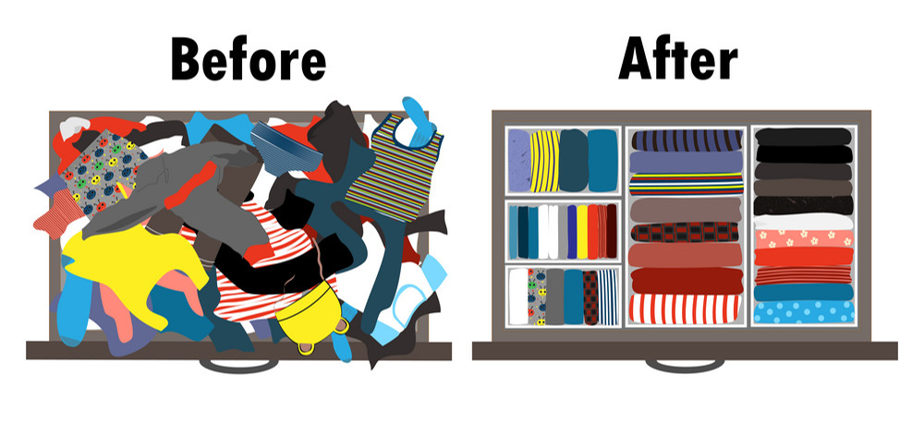

To structure our code better we need to be able to group a collection of code together into one object. This can be done in two ways:

- converting to functions
- converting to classes

Classes are beyond the scope of this course and are less prevalent in R, so we will focus on functions here. However, many of these principles can also be applied to classes.

Properties of functions:

- functions complete a task
- functions can take inputs and give outputs

Well-named functions mean we do not need to understand the details inside the function - just what they achieve.

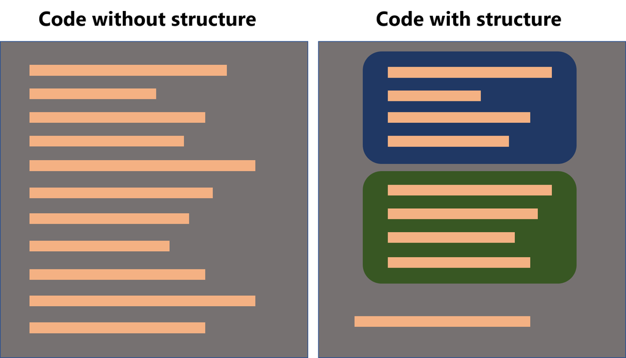

Within this course there is a **programming styles** document, explaining some of the different styles of programming. This is suggested further reading at this point in the course.

There are some important principles to keep in mind when we design functions:

- functions should not have “side-effects”. Data outside the function should not be impacted by using the function
- functions should serve a single purpose

# 3 Scripts to Functions

In this section we will discuss considerations when converting scripts to functions. In this section we will use an example script to show the steps involved structuring code.

## 3.1 Example Analysis Code

The code that has been given to you by your colleague is given in this section. At present it is a script that is well commented, but not well structured. Your task is to structure the code allowing for future reproducible analysis.

At a high level, the code:

- loads in the two data sets
- cleans the data
- joins the data so all useful information is together
- calculates an aggregate statistic
- tidies the output data
- writes the data to a CSV file

Have a read through the script you have received, be sure to look up any sections you are not comfortable with.

If you would prefer to look at it within an IDE it is located in

- `/course_content/example_code_python/initial_script/`
- `/course_content/example_code_R/initial_script/`.

For all scripts and files throughout this course it is assumed that the working directory being used is the location of the file being run. This may need to be changed in your given IDE.

Within RStudio this is done using:

“Session” > “Set Working Directory” > “To Source File Location”

Within Spyder, this will depend on your version.

“Tools” > “Preferences” > “Run” > “Default working directory is” -> *the script directory*

Python and R versions of the code are available.

### Python

```python
# File to analyse the mean population density data from the UN

# Import relevant libraries for analysis
import pandas as pd
import os

# Load the population density data 2019
population_path = os.path.join("../../data/population_density_2019.csv")
pop_density = pd.read_csv(population_path)

# Clean the column names, following naming conventions similar to PEP8
pop_density.columns = pop_density.columns.str.lower()
pop_density.columns = pop_density.columns.str.replace(" ", "_")

# The country_and_parent_code column needs to
# be split into two columns without the strings
pop_density[["country_code", "parent_code"]] = (pop_density["country_and_parent_code"]
                                                .str.split("_", expand=True))

# Remove the country_and_parent_code and parent_code columns, not used in later analysis
# axis=1 to remove the columns
pop_density = pop_density.drop(labels=[
                                       "country_and_parent_code",
                                       "parent_code"
                                       ],
                               axis=1)

# Convert country_code to integer by removing strings
pop_density["country_code"] = pop_density["country_code"].str.replace("CC", "")
pop_density["country_code"] = pop_density["country_code"].astype(int)


# Load the locations data to get the Sustainable Development Goals sub regions
locations_path = os.path.join("../../data/locations.csv")
locations = pd.read_csv(locations_path)

# Clean the column names, following naming conventions similar to PEP8
locations.columns = locations.columns.str.lower()
locations.columns =  locations.columns.str.replace(" ", "_")

# The location_id data has quotation marks making it a string,
# it needs to be converted to a numeric
locations["location_id"] = locations["location_id"].str.replace('"', '')
locations["location_id"] = locations["location_id"].astype(int)

# Join the data sets
# Left merge so we keep all pop_density data
pop_density_location = pop_density.merge(locations,
                                         how="left",
                                         left_on="country_code",
                                         right_on="location_id")

# Remove the location_id column as it is equal to country_code or missing
pop_density_location = pop_density_location.drop(labels=["location_id"], axis=1)

# Get just the relevant columns in preparation
# for the following groupby
region_density = pop_density_location[["sdg_region_name", "population_density"]]

# Calculate the mean population density for each region
# A non-weighted mean
region_mean_density = (region_density.groupby('sdg_region_name', as_index=False)
                       .agg({"population_density": "mean"}))

region_mean_density = region_mean_density.rename(columns={"population_density": "mean_population_density"})

# Sort the data for clearer reading
region_mean_density = region_mean_density.sort_values(by="mean_population_density",
                                                      ascending=False)

# Round mean density for clearer reading
region_mean_density["mean_population_density"] = region_mean_density["mean_population_density"].round(2)

# Write out the final output
region_mean_density.to_csv("mean_population_density_output.csv", index=False)
```

Output data:

| sdg_region_name | mean_population_density |
| --- | --- |
| Eastern and South-Eastern Asia | 2112.67 |
| Europe and Northern America | 764.93 |
| Central and Southern Asia | 330.63 |
| Northern Africa and Western Asia | 234.38 |
| Latin America and the Caribbean | 199.62 |
| Oceania (excluding Australia and New Zealand) | 144.20 |
| Sub-Saharan Africa | 126.55 |
| Australia/New Zealand | 10.72 |

### R

```python
# File to analyse the mean population density data from the UN

# Import relevant libraries for analysis
library(tidyr)
library(dplyr)
library(stringr)
library(readr)

# Load the population density data 2019
population_path <- file.path("../../data/population_density_2019.csv")
pop_density <- readr::read_csv(population_path)

# Clean the column names, following snake_case convention
colnames(pop_density) <- tolower(colnames(pop_density))
colnames(pop_density) <- stringr::str_replace_all(colnames(pop_density), pattern = " ", replacement = "_")


# The country_and_parent_code column needs to
# be split into two columns without the strings
pop_density <- tidyr::separate(data = pop_density, col = country_and_parent_code,
                               into = c("country_code", "parent_code"),
                               sep = "_")


# Remove the  parent_code column, not used in later analysis
pop_density <- dplyr::select(pop_density, everything(), -parent_code)

# Convert country_code to integer by removing strings
pop_density$country_code <- stringr::str_remove_all(pop_density$country_code, pattern = "CC")
pop_density$country_code <- as.integer(pop_density$country_code)


# Load the locations data to get the Sustainable Development Goals sub regions
locations_path <- file.path("../../data/locations.csv")
locations <- readr::read_csv(locations_path)

# Clean the column names, following naming conventions similar to PEP8
colnames(locations) <- tolower(colnames(locations))
colnames(locations) <- stringr::str_replace_all(colnames(locations), pattern = " ", replacement = "_")

# The location_id data has quotation marks making it a string,
# it needs to be converted to a numeric
locations$location_id <- stringr::str_remove_all(locations$location_id, pattern = '"')
locations$location_id <- as.integer(locations$location_id)


# Change location_id to be called country_code for join
colnames(locations)[colnames(locations) == "location_id"] <- "country_code"

# Join the data sets
# Left merge so we keep all pop_density data
pop_density_location <- dplyr::left_join(pop_density,
                                         locations,
                                         by = "country_code")


# Get just the relevant columns in preparation
# for the following groupby
region_density <- dplyr::select(pop_density_location, sdg_region_name, population_density)

# Calculate the mean population density for each region
# A non-weighted mean

region_density_grouped <- dplyr::group_by(region_density, sdg_region_name)

region_mean_density <- dplyr::summarise(region_density_grouped,
                                        "mean_population_density" = mean(population_density)
                                        )

# Sort the data for clearer reading, descending order
region_mean_density <- dplyr::arrange(region_mean_density,  -mean_population_density)

# Round mean density for clearer reading
region_mean_density$mean_population_density <- round(region_mean_density$mean_population_density,
                                                     digits = 2)

# Write out the final output
readr::write_csv(x = region_mean_density, file = "mean_population_density_output.csv")
```

Output data:

| sdg_region_name | mean_population_density |
| --- | --- |
| Eastern and South-Eastern Asia | 2112.67 |
| Europe and Northern America | 764.93 |
| Central and Southern Asia | 330.63 |
| Northern Africa and Western Asia | 234.38 |
| Latin America and the Caribbean | 199.62 |
| Oceania (excluding Australia and New Zealand) | 144.20 |
| Sub-Saharan Africa | 126.55 |
| Australia/New Zealand | 10.72 |

## 3.2 Grouping Code by Functionality

Chunks of code that do similar things should be grouped together.

Deciding which sections of code make sense as being part of the same function is a common challenge when structuring code.

When converting code into a function - the main thing we look for is that it achieves one task. It may take us a few lines of code to achieve this “one task” - but the point is the function has a specific purpose.

> If a function has more than one task or “responsibility” it will become hard to maintain, as it has many reasons to be modified.

> If a function has a single “responsibility”, it will be focussed and much more likely to be reusable elsewhere.

When writing scripts, we often repeat the same tasks at different points in the script. These are good parts of code to start converting into functions. Doing so reduces the amount of code written in the file - and makes what is happening at any step clearer.

You may also wish to consider writing **helper functions** for any common housekeeping tasks that you tend to commonly require.

If a code block isn’t repeated throughout the code that’s okay too - all the code can be converted to functions to be called one after the other.

It is much easier to read a sequence of well-named functions, rather than a long stream of commands.

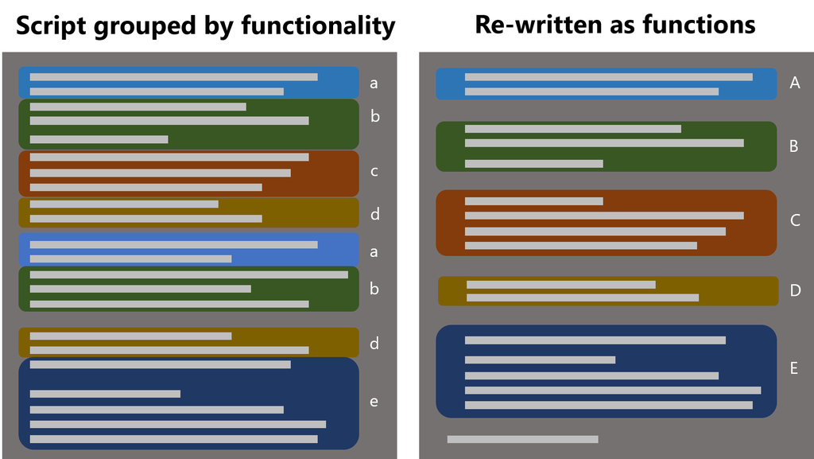

Some code is often very similar, with a variable or two difference in areas of the code. When reading the code, it’s important to think about what is happening to the variables and data involved. Consider whether a similar process is happening elsewhere, rather than whether the same data is involved. These repeating processes present opportunities to reduce the overall length of your script by writing your own custom functions.

Returning to our example script, we are going to take one task, convert it into a function, then improve the function so it can be used multiple times.

The lines of code:

- load in a data frame given a path
- reformat the column names of the data frame

### Initial Code

#### Python

```python
# Import relevant libraries for analysis
import pandas as pd
import os

# Load the population density data 2019
population_path = os.path.join("../../data/population_density_2019.csv")
pop_density = pd.read_csv(population_path)

# Clean the column names, following naming conventions similar to PEP8
pop_density.columns = pop_density.columns.str.lower()
pop_density.columns = pop_density.columns.str.replace(" ", "_")
```

#### R

```r
# Load the population density data 2019
pop_density <- readr::read_csv("../../data/population_density_2019.csv")

# Clean the column names, following snake_case convention
colnames(pop_density) <- tolower(colnames(pop_density))
colnames(pop_density) <- stringr::str_replace_all(colnames(pop_density),
                                                  pattern = " ",
                                                  replacement = "_")
```

### Basic Function

We can wrap the code into a function so that all the code can be run with one command like so.

#### Python

```python
def load_formatted_pop_frame()
    """Read population data and reformat column names"""
    # Load the population density data 2019
    population_path = os.path.join("../../data/population_density_2019.csv")
    pop_density = pd.read_csv(population_path)

    # Clean the column names, following naming conventions similar to PEP8
    pop_density.columns = pop_density.columns.str.lower()
    pop_density.columns = pop_density.columns.str.replace(" ", "_")

    return pop_density

# Call the function to assign the data frame

population_density = load_formatted_pop_frame()
```

#### R

```r
#' Read population data and reformat column names
load_formatted_pop_frame <- function() {
  # Load the population density data 2019
  population_path <- file.path("../../data/population_density_2019.csv")
  pop_density <- readr::read_csv(population_path)

  # Clean the column names, following snake_case convention
  colnames(pop_density) <- tolower(colnames(pop_density))
  colnames(pop_density) <- stringr::str_replace_all(colnames(pop_density),
                                                    pattern = " ",
                                                    replacement = "_")

  return(pop_density)
}

# Call the function to assign the data frame
population_density <- load_formatted_pop_frame()
```

### Adding Parameters

To improve the function, we can add as an argument something that may change in the future - the path of the data string.

Consider how you would have to change the previous function if the location of the `population_density_2019.csv` file changed.

Variable names in functions should reflect what that variable is. If you don’t know exactly the value the variable will take, then a generic name like `dataframe` is appropriate. Though consider the framework that you are working in - avoid reserved words or well-established, commonly used function names.

When we add an argument to a function replacing a value within, we need to be sure to change all times that original variable was used.

Our comments should reflect the changes made too.

> Note that comments should add information - the comments in this tutorial are reminders of why we are doing this, and not the style of comment you would be expected to write. Often, if functions and variables are well-named, the code does not require many comments.

#### Python

The new function can now be used for both the `population_density` data and `locations.csv`.

```python
def load_formatted_frame(path_to_data):
    """Read csv and reformat column names"""
    # Load the csv from given path
    formatted_path = os.path.join(path_to_data)
    dataframe = pd.read_csv(formatted_path)

    # Clean the column names, following naming conventions similar to PEP8
    dataframe.columns = dataframe.columns.str.lower()
    dataframe.columns = dataframe.columns.str.replace(" ", "_")

    return dataframe

# The path can be updated where the function is run if needed
population_density = load_formatted_frame("../../data/population_density_2019.csv")

# The same function is used to load a formatted locations.csv
locations = load_formatted_frame("../../data/locations.csv")
```

#### R

The new function can now be used for both the `population_density` data and `locations.csv`.

```r
#' Read population data and reformat column names
load_formatted_frame <- function(path_to_data) {
  # Load the population density data 2019
  formatted_path <- file.path(path_to_data)
  dataframe <- readr::read_csv(formatted_path)

  # Clean the column names, following snake_case convention
  colnames(dataframe) <- tolower(colnames(dataframe))
  colnames(dataframe) <- stringr::str_replace_all(colnames(dataframe), pattern = " ", replacement = "_")

  return(dataframe)
}

# The path can be updated where the function is run if needed
population_density <- load_formatted_frame("../../data/population_density_2019.csv")

# The same function is used to load a formatted locations.csv
locations <- load_formatted_frame("../../data/locations.csv")
```

## 3.3 Scope

Scope is an important concept when creating functions and structuring code.

> Scope refers to the places in a program that a variable can be accessed.

When writing scripts, variables can be accessed anywhere in the script - so long as the variable assignment has been run.

When we write scripts, we are storing all our variables at the highest, most accessible area of the program. This is referred to as “Global Scope”.

> Variables with global scope are accessible in all locations of the program.

This is the easiest way to store variables when learning to program.

However, using global variables throughout our analysis often creates unexpected results in our code. If a new piece of code accidentally alters a global variable, it will affect all the code run after it, even if the function wasn’t meant to update the variable… errors like this can be very tricky to track down and fix.

Some variables can only be accessed in certain locations within a program. When this happens, it is referred to as “Local Scope”.

> Variables have local scope if they are accessible within a part of a program such as a function. They cannot be accessed outside the function they are assigned in.

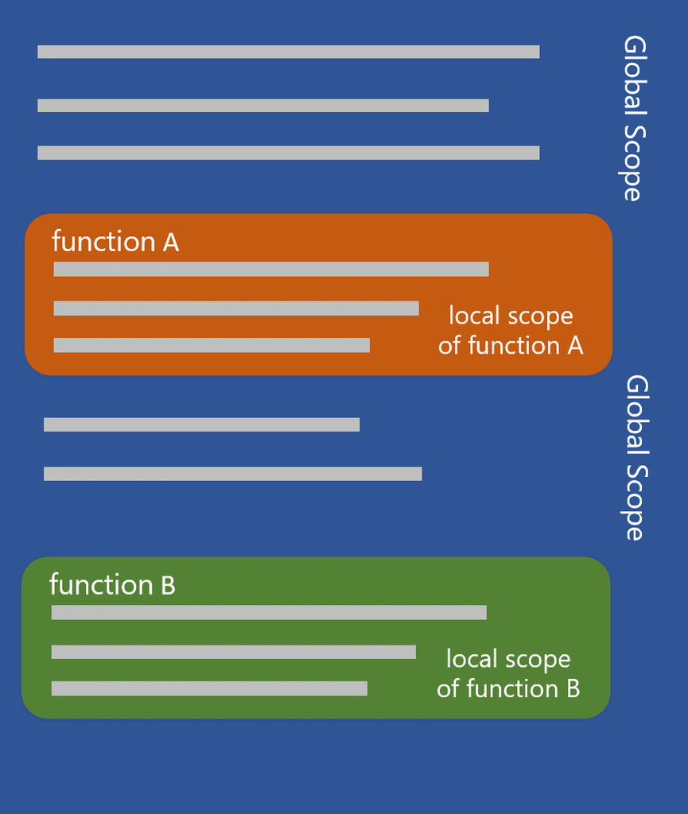

At the highest level of scope are the parts of the programming language that can be accessed anywhere - the built in functions (e.g. `print()`).

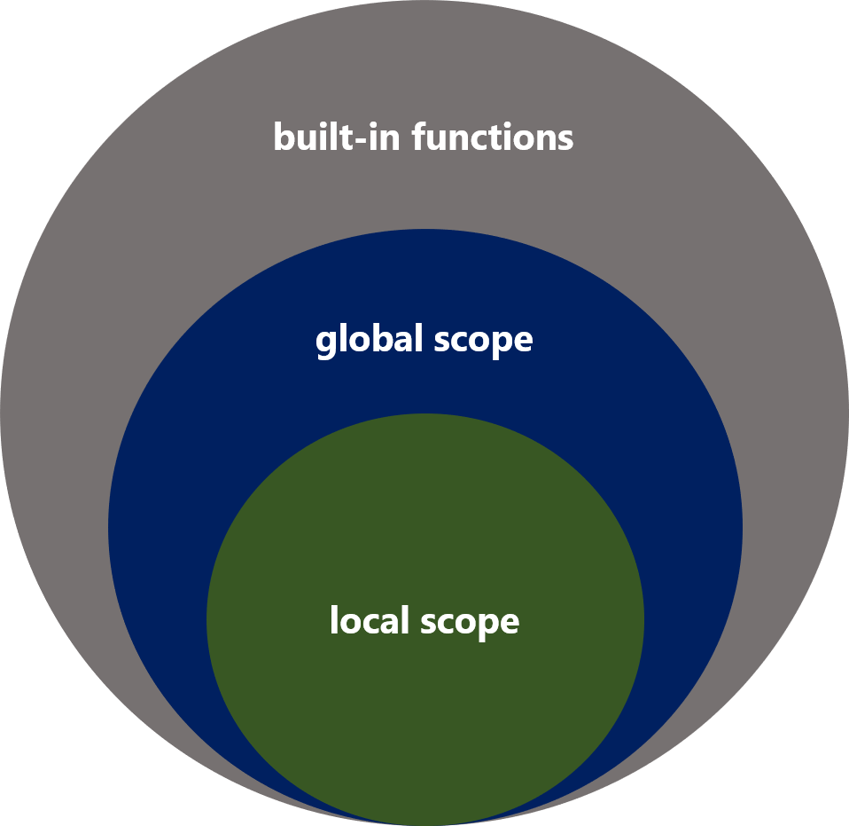

To make our functions follow functional programming principles we need to keep variable scope in mind.

When designing functions:

- all variables within should either:
  - be passed as arguments to the function
  - be created within the function
- variables with Global Scope should only be given as arguments to the function
  - although all function can access global variables, doing so makes our code harder to understand
- if we need to access data with local scope (within a function) it needs to be returned by the function

If we are clear about what variables we are accessing, we can be sure about what their values are. Using only variables passed as arguments clarifies what data a function is operating on, and makes it much easier to reuse elsewhere (as it just needs its arguments defined, no hidden dependencies on global variables).

Think of your functions as having an entrance and an exit.

- the entrance is the arguments and variables it takes as inputs
- the exit is the value it returns

When choosing which parameters to give a function there are a few things to consider:

- scope
- clarity - avoid bundling parameters together into an object, make sure each parameter is clearly named
- purpose - only include parameters needed for the task

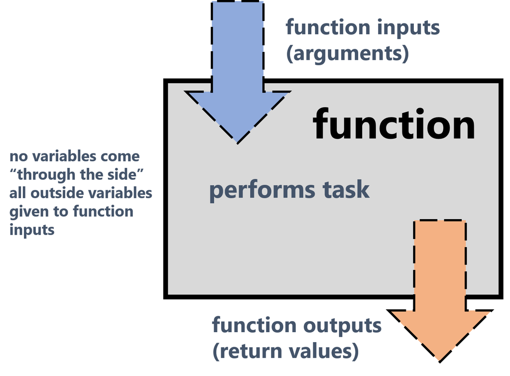

Not all functions need to return a value, such as a function that writes out a file. In this case do not use a return statement, making it clear nothing will be returned. By default if there is no return statement in a function:

- Python will return `None`
- R will return `NULL`

### 3.3.1 Function Inputs

Below are examples of code which have similar purposes, one uses parameter variables well, the other does not.

#### Python

##### Bad Input

This is bad because we are altering data that has not been passed as arguments to the function.

```python
letters = ["a", "b", "c", "d", "e"]

def add_letter():
    long_letters  = letters + ["f"]
    return long_letters

# Run on original data
print(add_letter())

# the value of letters could be changed elsewhere in the program
```

```
## ['a', 'b', 'c', 'd', 'e', 'f']
```

```python
letters = ["1", "2", "3", "4", "5"]

# Without changing our function call at all we get a different result
# with the same function call
print(add_letter())
```

```
## ['1', '2', '3', '4', '5', 'f']
```

##### Better Input

This is better because the function is more clearly dependent on the input values.

```python
letters = ["a", "b", "c", "d", "e"]

def add_letter(charcter_list):
    long_letters = charcter_list + ["f"]
    return long_letters

# Run on the original data
print("Initial")
```

```
## Initial
```

```python
print(add_letter(letters))

# If the data changes later so does our result
```

```
## ['a', 'b', 'c', 'd', 'e', 'f']
```

```python
letters = ["1", "2", "3", "4", "5"]

# This time we can see why the result is different
# We need to check the value of `letters`
print("Changed")
```

```
## Changed
```

```python
print(add_letter(letters))
```

```
## ['1', '2', '3', '4', '5', 'f']
```

#### R

##### Bad Input

This is bad because we are altering data that has not been passed as arguments to the function.

```r
letters <- c("a", "b", "c", "d", "e")

add_letter <- function() {
    long_letters <- c(letters, "f")
    return(long_letters)
}

# Run on original data
print("Initial")
```

```
## [1] "Initial"
```

```r
print(add_letter())
```

```
## [1] "a" "b" "c" "d" "e" "f"
```

```r
# the value of letters could be changed elsewhere in the program
letters <- c("1", "2", "3", "4", "5")

# Without changing our function call at all we get a different result
# with the same function call
print("Changed")
```

```
## [1] "Changed"
```

```r
print(add_letter())
```

```
## [1] "1" "2" "3" "4" "5" "f"
```

##### Better Input

```r
letters <- c("a", "b", "c", "d", "e")

add_letter <- function(character_vector) {
    long_characters <- c(character_vector, "f")
    return(long_characters)
}

# Run on original data
print("Initial")
```

```
## [1] "Initial"
```

```r
print(add_letter(letters))
```

```
## [1] "a" "b" "c" "d" "e" "f"
```

```r
# the value of letters could be changed elsewhere in the program
letters <- c("1", "2", "3", "4", "5")

# Without changing our function call at all we get a different result
# with the same function call
print("Changed")
```

[output not shown]

```
## [1] "Changed"
```

### 3.3.2 Data Frame Considerations

As analysts and data scientists, we will often use data frames in our programs.

There are some special considerations that need to be taken when working with these objects, with regards to functional programming principles.

#### Python

We need to avoid unintentionally altering an existing object when we give them to functions.

This is primarily a challenge in Python / `pandas` rather than in R, due to Python being a more object oriented language.

If we give a data frame to a function, some `pandas` code can edit the original data frame “in-place” from outside of the scope of the function.

This means any other variables in the code referring to that data frame will be changed unintentionally.

Below is an example of the unintentional effect this can have.

```python
import pandas as pd

initial_frame = pd.DataFrame(columns=["first", "second"])

print("initial_frame before function called:", initial_frame)
```

```
## initial_frame before function called: Empty DataFrame
## Columns: [first, second]
## Index: []
```

```python
def add_values(dataframe):

    dataframe[["first", "second"]] = pd.Series(["value1, value2"]).str.split(", ", expand=True)

    return dataframe


changed_frame = add_values(initial_frame)

print("changed_frame:", changed_frame)
```

```
## changed_frame:     first  second
## 0  value1  value2
```

```python
print("initial_frame after function called:", initial_frame)

# Without intending we have edited the inital_frames
```

```
## initial_frame after function called:     first  second
## 0  value1  value2
```

```python
print("Inital and new frame are equal:", initial_frame.equals(changed_frame))
```

```
## Inital and new frame are equal: True
```

There are different approaches to prevent this phenomena. We will look at one in-particular to tackle the problem.

##### Local Copy

A local copy of the original dataframe can be made within each function that takes as a parameter a data frame. This local copy is worked with and manipulated, then returned.

This prevents the original object from being changed.

The `.copy()` method is used to achieve this.

```python
import pandas as pd

initial_frame = pd.DataFrame(columns=["first", "second"])

print("initial_frame before function called:", initial_frame)
```

```
## initial_frame before function called: Empty DataFrame
## Columns: [first, second]
## Index: []
```

```python
def add_values(dataframe):
    # Typically the original data frame name is overwritten
    # This avoids potential naming issues
    dataframe = dataframe.copy()

    dataframe[["first", "second"]] = pd.Series(["value1, value2"]).str.split(", ", expand=True)

    return dataframe


changed_frame = add_values(initial_frame)

print("changed_frame:", changed_frame)
```

```
## changed_frame:     first  second
## 0  value1  value2
```

```python
print("initial_frame after function called:", initial_frame)

# Check if we have edited the original
```

```
## initial_frame after function called: Empty DataFrame
## Columns: [first, second]
## Index: []
```

```python
print("Inital and new frame are equal:", initial_frame.equals(changed_frame))
```

```
## Inital and new frame are equal: False
```

This approach helps to prevent side effects of our functions.

There is however a trade-off - as we make more copies of data our memory usage will increase.

While this is rarely a problem for small data sets, it is something to keep in mind as your projects get bigger.

There are design approaches that can be used to reduce the memory usage of your program.

For example, removing unneeded data and duplicates, piping and manipulating data with `inplace` parameters can help.

#### R

R has a number of properties that make it an effective langauge for writing functions.

There are some considerations that need to be taken into account when passing parameters to functions in R, especially when using the `tidyverse` family of functions.

##### From Strings to Variables

When we convert a script to a function we often need to put variable names in our code instead of strings / names.

For example, if we want to write a function that takes a data frame and column name as a parameter.

These variables need to be handled slightly differently than the strings they once were.

For example, when accessing a column name we can specify the name using `$`, or we can use square brackets `[]`, which also works with columns.

Assuming we have some data frame `survey` with a column `"people"`.

```r
# To access column "people" from the dataframe "survey"
survey$people

# To access the column name stored as a variable, "people" from "survey"
column_name <- "people"

survey[column_name]
```

To access the specific column needed you can use single square brackets `survey[column_name]`.

To access the specific vector of values in a column you use double square brackets `survey[[column_name]]`.

##### Lazy Evaluation

By default in R when variables are given to functions their values will not be evaluated.

This means if we pass column names into the function as variables they will not be recognised as names of columns themselves.

When using `tidyverse` functions this issue can be avoided in two ways.

```r
# This code will not run

column_name <- "people"

grouped_survey <- dplyr::group_by(.data = survey, column_name)
```

We can either use standard evaluation function versions, these are given with an underscore at the end of a function name.

```r
# This code will run

column_name <- "people"

grouped_survey <- dplyr::group_by_(.data = survey, column_name)
```

Alternatively, we can use the `dplyr` function `get()` to evaluate a variable we give to it.

```r
# This code will run

column_name <- "people"

grouped_survey <- group_by(.data = survey, get(col_name))
```

In functions we pass variables to other functions frequently, so it is important to be able to access those variables.

## 3.4 Exercises

### Exercise 1

Using the code snippets from the example analysis below, write a function that:

- takes an input population density data frame
- splits the `country_and_parent_code` column into `parent_code` and `country_code` columns
- drops the `country_and_parent_code` and `parent_code` columns
- returns the new data frame

Add this function into the file `example_code_python/function_input/exercise1.py` or `example_code_R/function_input/exercise1.R` depending on your chosen framework. Use the code already there to test your result on `pop_density`.

Name the function `access_country_code()`.

#### Python snippet

```python
# The country_and_parent_code column needs to
# be split into two columns without the strings
pop_density[["country_code", "parent_code"]] = (pop_density["country_and_parent_code"]
                                                .str.split("_", expand=True))

# Remove the country_and_parent_code and parent_code columns, not used in later analysis
# axis=1 to remove the columns
pop_density = pop_density.drop(labels=[
                                       "country_and_parent_code",
                                       "parent_code"
                                       ],
                               axis=1)
```

#### R snippet

```r
# The country_and_parent_code column needs to
# be split into two columns without the strings
pop_density <- tidyr::separate(data = pop_density, col = country_and_parent_code,
                               into = c("country_code", "parent_code"), sep = "_")

# Remove the  parent_code column, not used in later analysis
pop_density <- dplyr::select(pop_density, everything(), -parent_code)
```

### Answer 1

**Click for Python Answer**

```python
import pandas as pd
import os

## Code to be improved to complete exercise 1

def load_formatted_frame(path_to_data):
    """Read csv and reformat column names"""
    formatted_path = os.path.join(path_to_data)
    # Load the csv from given path
    dataframe = pd.read_csv(formatted_path)

    # Clean the column names, following naming conventions similar to PEP8
    dataframe.columns = dataframe.columns.str.lower()
    dataframe.columns = dataframe.columns.str.replace(" ", "_")

    return dataframe


def access_country_code(dataframe):
    """Function to split combined code columns and remove uncessary columns"""

    # Copy the incoming data to prevent editing the original
    dataframe = dataframe.copy()

    dataframe[["country_code", "parent_code"]] = (dataframe["country_and_parent_code"]
                                                .str.split("_", expand=True))

    dataframe_dropped = dataframe.drop(labels=[
                                                 "country_and_parent_code",
                                                 "parent_code"
                                              ], axis=1)
    return dataframe_dropped


# Loading both data frames

pop_density = load_formatted_frame("../../data/population_density_2019.csv")
locations = load_formatted_frame("../../data/locations.csv")


pop_density_single_code = access_country_code(pop_density)
print(pop_density_single_code["country_code"])
```

**Click for R Answer**

```r
library(tidyr)
library(dplyr)
library(stringr)
library(readr)

## Code to be improved to complete exercise 1


#' Read population data and reformat column names
load_formatted_frame <- function(path_to_data) {
  # Load the population density data 2019
  formatted_path <- file.path(path_to_data)
  dataframe <- readr::read_csv(formatted_path)

  # Clean the column names, following snake_case convention
  colnames(dataframe) <- tolower(colnames(dataframe))
  colnames(dataframe) <- stringr::str_replace_all(colnames(dataframe), pattern = " ", replacement = "_")

  return(dataframe)
}


#' Function to split combined code columns
#' and remove uncessary columns
access_country_code <- function(dataframe) {
  # The country_and_parent_code column needs to
  # be split into two columns without the strings
  dataframe <- tidyr::separate(data = dataframe, col = country_and_parent_code,
                               into = c("country_code", "parent_code"),
                               sep = "_")

  # Remove the  parent_code column, not used in later analysis
  dataframe <- dplyr::select(dataframe, everything(), -parent_code)

  return(dataframe)
}


# Loading both data frames
population_density <- load_formatted_frame("../../data/population_density_2019.csv")
locations <- load_formatted_frame("../../data/locations.csv")

# Run the code created checking output
pop_density_single_code <- access_country_code(population_density)
print(pop_density_single_code$country_code)
```

### Exercise 2

Using the code snippets from our example analysis below, write a function that:

- takes a data frame as an input
- can replace a string within a specified column
- can convert the type of a given column

This function will be used across both data frames later - so be sure it is general enough to work for both. In addition, it must use only data it gets as arguments.

Add this function into the file `example_code/function_input/exercise2.py|R`. Use the code already there to test your result on `locations` and `pop_density`.

Name the function `convert_type_to_int()`.

#### Python snippet

```python
# Replace specific string in column
locations["location_id"] = locations["location_id"].str.replace('"', '')

# Convert the type of the column
locations["location_id"] = locations["location_id"].astype(int)
```

#### R snippet

```r
# Convert country_code to integer by removing extra strings
pop_density$country_code <- stringr::str_remove(pop_density$country_code, pattern = "CC")

# Convert type
pop_density$country_code <- as.integer(pop_density$country_code)
```

### Answer 2

**Click for Python Answer**

```python
import pandas as pd
import os

## Code to be improved to complete exercise 2

def load_formatted_frame(path_to_data):
    """Read csv and reformat column names"""
    formatted_path = os.path.join(path_to_data)
    # Load the csv from given path
    dataframe = pd.read_csv(formatted_path)

    # Clean the column names, following naming conventions similar to PEP8
    dataframe.columns = dataframe.columns.str.lower()
    dataframe.columns = dataframe.columns.str.replace(" ", "_")

    return dataframe


def access_country_code(dataframe):
    """Function to split combined code columns and remove uncessary columns"""

    dataframe = dataframe.copy()

    dataframe[["country_code", "parent_code"]] = (dataframe["country_and_parent_code"]
                                                .str.split("_", expand=True))

    dataframe_dropped = dataframe.drop(labels=[
                                                 "country_and_parent_code",
                                                 "parent_code"
                                              ], axis=1)
    return dataframe_dropped



def convert_type_to_int(dataframe, column_name, string_value):
    """Function to convert string to integer column type"""

    dataframe = dataframe.copy()

    dataframe[column_name] = dataframe[column_name].str.replace(string_value, "")

    dataframe[column_name] = dataframe[column_name].astype(int)

    return dataframe


## Run the functions created

pop_density = load_formatted_frame("../../data/population_density_2019.csv")
locations = load_formatted_frame("../../data/locations.csv")


pop_density_single_code = access_country_code(pop_density)


pop_density_correct_types = convert_type_to_int(dataframe=pop_density_single_code,
                                                column_name="country_code",
                                                string_value="CC")

locations_correct_types = convert_type_to_int(dataframe=locations,
                                                column_name="location_id",
                                                string_value='"')

print(pop_density_correct_types.dtypes)
print(locations_correct_types.dtypes)
```

**Click for R Answer**

```r
library(tidyr)
library(dplyr)
library(stringr)
library(readr)

## Code to be improved to complete exercise 2


#' Read population data and reformat column names
load_formatted_frame <- function(path_to_data) {
  # Load the population density data 2019
  formatted_path <- file.path(path_to_data)
  dataframe <- readr::read_csv(formatted_path)

  # Clean the column names, following snake_case convention
  colnames(dataframe) <- tolower(colnames(dataframe))
  colnames(dataframe) <- stringr::str_replace_all(colnames(dataframe), pattern = " ", replacement = "_")

  return(dataframe)
}



#' Function to split combined code columns
#' and remove uncessary columns
access_country_code <- function(dataframe) {

  # The country_and_parent_code column needs to
  # be split into two columns without the strings
  dataframe <- tidyr::separate(data = dataframe, col = country_and_parent_code,
                               into = c("country_code", "parent_code"), sep = "_")


  # Remove the  parent_code column, not used in later analysis
  dataframe <- dplyr::select(dataframe, everything(), -parent_code)

  return(dataframe)
}


#' Function to convert string to integer column type
convert_type_to_int <- function(dataframe, column_name, string_value) {

  # Convert country_code to integer by removing extra strings
  # Using dataframe$column_name to get a column won't work when the column name is a variable
  dataframe[[column_name]] <- stringr::str_remove_all(dataframe[[column_name]], pattern = string_value)

  # Convert type
  dataframe[[column_name]] <- as.integer(dataframe[[column_name]])

  return(dataframe)
}




pop_density <- load_formatted_frame("../../data/population_density_2019.csv")
locations <- load_formatted_frame("../../data/locations.csv")

pop_density_single_code <- access_country_code(pop_density)

# Using the conversion function created
population_density_correct_types <- convert_type_to_int(pop_density_single_code,
                                                        column_name = "country_code",
                                                        string_value = "CC")

locations_correct_types <- convert_type_to_int(locations,
                                               column_name = "location_id",
                                               string_value = '"')

print(str(population_density_correct_types))
print(str(locations_correct_types))
```

### Exercise 3

Using the code snippets from our example analysis below, write a function that:

- takes two data frames as inputs
- takes two string inputs
- performs a left join on a column from each data frame, the columns are given by the strings input
- removes the second specified string column from the joined data frame
- returns a single data frame

This function will be used after the previous functions using the data frames outputted.

Add this function into the file `example_code_python|R/function_input/exercise3.py|r`. Use the code already there to test your result on the new data frame.

This function will be useful for our specific case, but also if we want to join other data frames or use different column names.

Our column names could change if we change an upstream function, so it’s important we give them as inputs.

Name the function `join_frames()`.

#### Python snippet

```python
# Join the data sets
# Left merge so we keep all pop_density data
pop_density_location = pop_density.merge(locations,
                                         how="left",
                                         left_on="country_code",
                                         right_on="location_id")

# Remove the location_id column as it is equal to country_code or missing
pop_density_location = pop_density_location.drop(labels=["location_id"], axis=1)
```

#### R snippet

```r
# Change location_id to be called country_code for join
locations <- dplyr::rename(locations, country_code = location_id)

# Join the data sets
# Left merge so we keep all pop_density data
pop_density_location <- dplyr::left_join(pop_density,
                                         locations,
                                         by = "country_code")


# Get just the relevant columns in preparation
# for the following groupby
region_density <- dplyr::select(pop_density_location, sdg_region_name, population_density)
```

### Answer 3

**Click for Python Answer**

```python
import pandas as pd
import os


def load_formatted_frame(path_to_data):
    """Read csv and reformat column names"""
    formatted_path = os.path.join(path_to_data)
    # Load the csv from given path
    dataframe = pd.read_csv(formatted_path)

    # Clean the column names, following naming conventions similar to PEP8
    dataframe.columns = dataframe.columns.str.lower()
    dataframe.columns = dataframe.columns.str.replace(" ", "_")

    return dataframe


def access_country_code(dataframe):
    """Function to split combined code columns and remove uncessary columns"""

    dataframe = dataframe.copy()

    dataframe[["country_code", "parent_code"]] = (dataframe["country_and_parent_code"]
                                                .str.split("_", expand=True))

    dataframe_dropped = dataframe.drop(labels=[
                                                 "country_and_parent_code",
                                                 "parent_code"
                                              ], axis=1)
    return dataframe_dropped



def convert_type_to_int(dataframe, column_name, string_value):
    """Function to convert string to integer column type"""

    dataframe = dataframe.copy()

    dataframe[column_name] = dataframe[column_name].str.replace(string_value, "")

    dataframe[column_name] = dataframe[column_name].astype(int)

    return dataframe


def join_frames(left_dataframe, right_dataframe, left_column, right_column):
    """
    Function to join the required frames on specified columns, dropping
    unrecessary column
    """

    left_dataframe = left_dataframe.copy()
    right_dataframe = right_dataframe.copy()

    combined_frames = left_dataframe.merge(right=right_dataframe,
                                           how="left",
                                           left_on=left_column,
                                           right_on=right_column)

    combined_frames_reduced = combined_frames.drop(labels=[right_column], axis=1)

    return combined_frames_reduced



## Run the functions created

pop_density = load_formatted_frame("../../data/population_density_2019.csv")
locations = load_formatted_frame("../../data/locations.csv")


pop_density_single_code = access_country_code(pop_density)


pop_density_correct_types = convert_type_to_int(dataframe=pop_density_single_code,
                                                column_name="country_code",
                                                string_value="CC")

locations_correct_types = convert_type_to_int(dataframe=locations,
                                                column_name="location_id",
                                                string_value='"')

population_location = join_frames(left_dataframe=pop_density_correct_types,
                                   right_dataframe=locations_correct_types,
                                   left_column="country_code",
                                   right_column="location_id")

print(population_location.columns)
print(population_location.head(10))
```

**Click for R Answer**

```r
library(tidyr)
library(dplyr)
library(stringr)
library(readr)

## Code to be improved to complete exercise 3


#' Read population data and reformat column names
load_formatted_frame <- function(path_to_data) {
  # Load the population density data 2019
  formatted_path <- file.path(path_to_data)
  dataframe <- readr::read_csv(formatted_path)

  # Clean the column names, following snake_case convention
  colnames(dataframe) <- tolower(colnames(dataframe))
  colnames(dataframe) <- stringr::str_replace_all(colnames(dataframe), pattern = " ", replacement = "_")

  return(dataframe)
}


#' Function to split combined code columns
#' and remove uncessary columns
access_country_code <- function(dataframe) {
  # The country_and_parent_code column needs to
  # be split into two columns without the strings
  dataframe <- tidyr::separate(data = dataframe, col = country_and_parent_code,
                               into = c("country_code", "parent_code"), sep = "_")


  # Remove the  parent_code column, not used in later analysis
  dataframe <- dplyr::select(dataframe, everything(), -parent_code)

  return(dataframe)
}


#' Function to convert string to integer column type
convert_type_to_int <- function(dataframe, column_name, string_value) {

  # Convert country_code to integer by removing extra strings
  # Using dataframe$column_name to get a column won't work when the column name is a variable
  dataframe[[column_name]] <- stringr::str_remove_all(dataframe[[column_name]], pattern = string_value)

  # Convert type
  dataframe[[column_name]] <- as.integer(dataframe[[column_name]])

  return(dataframe)
}

#' join the required frames on specified columns,
#' dropping unecessary columns
join_frames <- function(left_dataframe, right_dataframe, left_column, right_column) {

  # Change location_id to be called country_code for join
  colnames(right_dataframe)[colnames(right_dataframe) == right_column] <- left_column

  combined_frames <- dplyr::left_join(x = left_dataframe,
                                      y = right_dataframe,
                                      by = left_column)

  combined_frames_reduced <- dplyr::select(combined_frames, sdg_region_name, population_density)

  return(combined_frames_reduced)
}


## Run the functions created

pop_density <- load_formatted_frame("../../data/population_density_2019.csv")
locations <- load_formatted_frame("../../data/locations.csv")


pop_density_single_code <- access_country_code(pop_density)


pop_density_correct_types <- convert_type_to_int(dataframe=pop_density_single_code,
                                                column_name="country_code",
                                                string_value="CC")

locations_correct_types <- convert_type_to_int(dataframe=locations,
                                              column_name="location_id",
                                              string_value='"')

population_location <- join_frames(pop_density_correct_types,
                                   locations_correct_types,
                                   left_column = "country_code",
                                   right_column = "location_id")

print(colnames(population_location))
print(head(population_location, 10))
```

## 3.5 High Level Functions

This section will introduce some concepts and good practice that are relevant for when you have converted your script into functions.

In the section below, a version of code with all tasks broken into functions is shown. To help consolidate your learning from the previous exercises, an extension exercise is to convert the remaining code to functions yourself.

### 3.5.1 Final Script Conversion

#### Extension Exercise

Each of these functions perform one task. They are general enough that they work for our specific situation but leave some room for if we wanted to make minor adjustments upstream, such as column or filenames.

Side Note: We are writing the function `write_output()` as practice, it only contains one single line of code so in practice it wouldn’t be used as a function. It’s important to avoid writing functions that are too small.

**Click for Python Answer**

```python
import pandas as pd
import os


def load_formatted_frame(path_to_data):
    """Read csv and reformat column names"""
    formatted_path = os.path.join(path_to_data)
    # Load the csv from given path
    dataframe = pd.read_csv(formatted_path)

    # Clean the column names, following naming conventions similar to PEP8
    dataframe.columns = dataframe.columns.str.lower()
    dataframe.columns = dataframe.columns.str.replace(" ", "_")

    return dataframe


def access_country_code(dataframe):
    """Function to split combined code columns and remove uncessary columns"""

    dataframe = dataframe.copy()

    dataframe[["country_code", "parent_code"]] = (dataframe["country_and_parent_code"]
                                                .str.split("_", expand=True))

    dataframe_dropped = dataframe.drop(labels=[
                                                "country_and_parent_code",
                                                "parent_code"
                                              ], axis=1)
    return dataframe_dropped



def convert_type_to_int(dataframe, column_name, string_value):
    """Function to convert string to integer column type"""

    dataframe = dataframe.copy()

    dataframe[column_name] = dataframe[column_name].str.replace(string_value, "")

    dataframe[column_name] = dataframe[column_name].astype(int)

    return dataframe


def join_frames(left_dataframe, right_dataframe, left_column, right_column):
    """
    Function to join the required frames on specified columns, dropping
    unrecessary column
    """

    left_dataframe = left_dataframe.copy()
    right_dataframe = right_dataframe.copy()


    combined_frames = left_dataframe.merge(right=right_dataframe,
                                           how="left",
                                           left_on=left_column,
                                           right_on=right_column)

    combined_frames_reduced = combined_frames.drop(labels=[right_column], axis=1)

    return combined_frames_reduced


def aggregate_mean(dataframe, groupby_column, statistic_column):
    """Function to groupby and calculate the aggregate mean of two columns"""

    dataframe = dataframe.copy()

    # Remove unecessary columns
    subset = dataframe[[groupby_column, statistic_column]]

    # Perform mean calculation
    statistic = (subset.groupby(groupby_column, as_index=False)
                       .agg({statistic_column: "mean"}))

    statistic_renamed = statistic.rename(columns={statistic_column: "mean_" + aggregate_column})

    return statistic_renamed



def format_frame(dataframe, statistic_column):
    """Function to format the dataframe for output"""

    dataframe = dataframe.copy()

    dataframe_sorted = dataframe.sort_values(by=statistic_column,
                                             ascending=False)

    dataframe_sorted[statistic_column] = dataframe_sorted[statistic_column].round(2)

    return dataframe_sorted


def write_output(dataframe, output_filepath):
    """Function to write output statistic in formatted manner"""

    dataframe.to_csv(output_filepath, index=False, sep=",")

    # We are not returning anything so our function
    # does not need a return value. By default this
    # will return `None`



## Run the functions created

pop_density = load_formatted_frame("../../data/population_density_2019.csv")
locations = load_formatted_frame("../../data/locations.csv")


pop_density_single_code = access_country_code(pop_density)


pop_density_correct_types = convert_type_to_int(dataframe=pop_density_single_code,
                                                column_name="country_code",
                                                string_value="CC")

locations_correct_types = convert_type_to_int(dataframe=locations,
                                              column_name="location_id",
                                              string_value='"')


population_location = join_frames(left_dataframe=pop_density_correct_types,
                                   right_dataframe=locations_correct_types,
                                   left_column="country_code",
                                   right_column="location_id")

aggreagation = aggregate_mean(dataframe=population_location,
                              groupby_column="sdg_region_name",
                              aggregate_column="population_density")

formatted_statistic = format_frame(aggreagation, "mean_population_density")

write_output(formatted_statistic, "./mean_pop_density.csv")
```

**Click for R Answer**

```r
library(tidyr)
library(dplyr)
library(stringr)
library(readr)



#' Read population data and reformat column names
load_formatted_frame <- function(path_to_data) {
  # Load the population density data 2019
  formatted_path <- file.path(path_to_data)
  dataframe <- readr::read_csv(formatted_path)

  # Clean the column names, following snake_case convention
  colnames(dataframe) <- tolower(colnames(dataframe))
  colnames(dataframe) <- stringr::str_replace_all(colnames(dataframe), pattern = " ", replacement = "_")

  return(dataframe)
}


#' Function to split combined code columns
#' and remove uncessary columns
access_country_code <- function(dataframe) {
  # The country_and_parent_code column needs to
  # be split into two columns without the strings
  dataframe <- tidyr::separate(data = dataframe, col = country_and_parent_code,
                               into = c("country_code", "parent_code"), sep = "_")


  # Remove the  parent_code column, not used in later analysis
  dataframe <- dplyr::select(dataframe, everything(), -parent_code)

  return(dataframe)
}


#' Function to convert string to integer column type
convert_type_to_int <- function(dataframe, column_name, string_value) {

  # Convert country_code to integer by removing extra strings
  # Using dataframe$column_name to get a column won't work when the column name is a variable
  dataframe[column_name] <- stringr::str_remove_all(dataframe[[column_name]], pattern = string_value)

  # Convert type
  dataframe[column_name] <- as.integer(dataframe[[column_name]])

  return(dataframe)
}

#' Join the required frames on specified columns,
#' dropping unecessary columns
join_frames <- function(left_dataframe, right_dataframe, left_column, right_column) {

  # Change location_id to be called country_code for join
  colnames(right_dataframe)[colnames(right_dataframe) == right_column] <- left_column

  combined_frames <- dplyr::left_join(x = left_dataframe,
                                      y = right_dataframe,
                                      by = left_column)

  combined_frames_reduced <- dplyr::select(combined_frames, sdg_region_name, population_density)

  return(combined_frames_reduced)
}


#' Function to groupby and calculate the mean of two columns
aggregate_mean <- function(dataframe, groupby_column, statistic_column) {

  # Perform aggregation and summary

  # Use group_by_ because of variable column name
  region_mean_density_grouped <- group_by_(.data = dataframe, groupby_column)

  # use get() to access column name
  region_mean_density <- dplyr::summarise(.data = region_mean_density_grouped,
                                          "mean_population_density" = mean(get(statistic_column)))

  return(region_mean_density)
}


#' Format the dataframe for output
format_frame <- function(dataframe, statistic_column) {

  # Sort the data for clearer reading, descending order
  dataframe_sorted <- dplyr::arrange(.data = dataframe)

  # Round mean density for clearer reading
  dataframe_sorted[statistic_column] <- round(dataframe_sorted[statistic_column],
                                             digits = 2)

  return(dataframe_sorted)
}

#' write output statistic in formatted manner
write_output <- function(dataframe, output_filepath) {

  readr::write_csv(x = dataframe, path = output_filepath)

}



## Run the functions created

pop_density <- load_formatted_frame("../../data/population_density_2019.csv")
locations <- load_formatted_frame("../../data/locations.csv")


pop_density_single_code <- access_country_code(pop_density)


pop_density_correct_types <- convert_type_to_int(dataframe = pop_density_single_code,
                                                 column_name = "country_code",
                                                 string_value = "CC")

locations_correct_types <- convert_type_to_int(dataframe = locations,
                                               column_name = "location_id",
                                               string_value = '"')

population_location <- join_frames(pop_density_correct_types,
                                   locations_correct_types,
                                   left_column = "country_code",
                                   right_column = "location_id")

aggreagation <- aggregate_mean(dataframe = population_location,
                              groupby_column = "sdg_region_name",
                              statistic_column = "population_density")

formatted_statistic <- format_frame(aggreagation, "mean_population_density")

write_output(formatted_statistic, "./mean_pop_density.csv")
```

### 3.5.2 Execute Program

Now we have converted all our code tasks into functions we can run each function, passing their output into the input of the next function.

Looking at the code at the end of our script there are a group of lines which describe the running of the program. These lines of code describe the whole analysis, showing each step in the process with a function corresponding to each step.

When we hit “Run” on our code, the code shown is run. The functions above it in the file are loaded into the program’s global scope, allowing them to be called by this code.

#### Python

```python
## Run the functions created

pop_density = load_formatted_frame("../../data/population_density_2019.csv")
locations = load_formatted_frame("../../data/locations.csv")


pop_density_single_code = access_country_code(pop_density)


pop_density_correct_types = convert_type_to_int(dataframe=pop_density_single_code,
                                                column_name="country_code",
                                                string_value="CC")

locations_correct_types = convert_type_to_int(dataframe=locations,
                                              column_name="location_id",
                                              string_value='"')

population_location = join_frames(left_dataframe=pop_density_correct_types,
                                   right_dataframe=locations_correct_types,
                                   left_column="country_code",
                                   right_column="location_id")

aggregation = aggregate_mean(dataframe=population_location,
                              groupby_column="sdg_region_name",
                              aggregate_column="population_density")

formatted_statistic = format_frame(aggregation, "mean_population_density")

write_output(formatted_statistic, output_filepath="./mean_pop_density.csv")
```

#### R

```r
## Run the functions created

pop_density <- load_formatted_frame("../../data/population_density_2019.csv")
locations <- load_formatted_frame("../../data/locations.csv")


pop_density_single_code <- access_country_code(pop_density)


pop_density_correct_types <- convert_type_to_int(dataframe = pop_density_single_code,
                                                 column_name = "country_code",
                                                 string_value = "CC")

locations_correct_types <- convert_type_to_int(dataframe = locations,
                                               column_name = "location_id",
                                               string_value = '"')

population_location <- join_frames(pop_density_correct_types,
                                   locations_correct_types,
                                   left_column = "country_code",
                                   right_column = "location_id")

aggreagation <- aggregate_mean(dataframe = population_location,
                              groupby_column = "sdg_region_name",
                              statistic_column = "population_density")

formatted_statistic <- format_frame(aggreagation, "mean_population_density")

write_output(formatted_statistic, "./mean_pop_density.csv")
```

### 3.5.3 Main Function

The code above makes what we are doing much easier to understand. To find out what the code is doing at each step, we can just read the name of the function, or look up what it does in the documentation.

The way the code is currently designed, however, still uses variables in the global scope, something to generally avoid.

If we add one more function, that calls our other functions, we can run our whole program by calling this one function. This will make it much easier to run the analysis later down the line, and to extend our code into modules and packages.

Functions that run other functions are called “high level” functions. Using high level functions lets us build more structure to our code.

Often the convention you will see for naming a highest level function in code is calling it `main()`, however it does not have to be this name. We will call our highest level analysis `get_analyse_output()`.

In effect, we put all the code that was used to “run” the program within the `get_analyse_output()` function. This way we can run the program only when we call `get_analyse_output()`.

This is the point where typical convention between Python and R starts to differ. Be sure to check both methods if you regularly code in both.

How many levels of “high level” functions we have should be proprortionate to our code. For a small task we probably don’t need high level functions. For a larger pipeline they become significantly more important.

#### Python

In Python there is an extra line of code we add to help us split our code into modules.

The line is as follows:

```python
if __name__ == "__main__":
    #Add your code to run here
```

When Python runs a file (module) the interpreter assigns it a value for the attribute `__name__`.

When we click “Run” in our IDE (such as Spyder), or run a script directly in command line, the `__name__` value of that file run is `"__main__"`.

If the file (module) is imported elsewhere in a program, then the value of `__name__` is not equal to `"__main__"`. It is instead assigned the name of the module file. Therefore any code within the block `if __name__ == "__main__":` will not be run.

At the moment, that is not very useful to us, but when we start expanding our code into multiple files (Convert to Modules) it becomes key.

If we want to alter the behaviour of the `get_analyse_output()` function we have two options:

- alter the main function to change variables passed to the function
- add parameters

Below is our `get_analyse_output()` function, and the code used to run it.

```python
def get_analyse_output():
    """
    Access the data, run the analysis of population density means over locations,
    output the data into a CSV.
    """

    pop_density = load_formatted_frame("../../data/population_density_2019.csv")
    locations = load_formatted_frame("../../data/locations.csv")

    pop_density_single_code = access_country_code(pop_density)

    pop_density_correct_types = convert_type_to_int(dataframe=pop_density_single_code,
                                                    column_name="country_code",
                                                    string_value="CC")

    locations_correct_types = convert_type_to_int(dataframe=locations,
                                                  column_name="location_id",
                                                  string_value='"')

    population_location = join_frames(left_dataframe=pop_density_correct_types,
                                       right_dataframe=locations_correct_types,
                                       left_column="country_code",
                                       right_column="location_id")

    aggregation = aggregate_mean(dataframe=population_location,
                                  groupby_column="sdg_region_name",
                                  aggregate_column="population_density")

    formatted_statistic = format_frame(aggregation, "mean_population_density")

    write_output(formatted_statistic, output_filepath="./mean_pop_density.csv")


if __name__ == "__main__":
    get_analyse_output()
```

If we were to use this analysis on different data sets, it may be useful for us to be able to change the data inputs and outputs.

```python
def get_analyse_output(population_filepath, location_filepath, output_filepath):
    """
    Access the data, run the analysis of population density means over locations,
    output the data into a CSV.
    """

    pop_density = load_formatted_frame(population_filepath)
    locations = load_formatted_frame(location_filepath)

    pop_density_single_code = access_country_code(pop_density)

    pop_density_correct_types = convert_type_to_int(dataframe=pop_density_single_code,
                                                    column_name="country_code",
                                                    string_value="CC")

    locations_correct_types = convert_type_to_int(dataframe=locations,
                                                  column_name="location_id",
                                                  string_value='"')

    population_location = join_frames(left_dataframe=pop_density_correct_types,
                                       right_dataframe=locations_correct_types,
                                       left_column="country_code",
                                       right_column="location_id")

    aggregation = aggregate_mean(dataframe=population_location,
                                  groupby_column="sdg_region_name",
                                  aggregate_column="population_density")

    formatted_statistic = format_frame(aggregation, "mean_population_density")

    write_output(formatted_statistic, output_filepath)



if __name__ == "__main__":
    get_analyse_output(population_filepath="../../data/population_density_2019.csv",
                       location_filepath="../../data/locations.csv",
                       output_filepath="./mean_pop_density.csv")
```

#### R

- alter the main function to change variables passed to the function
- add parameters

Below is our `get_analyse_output()` function, and the code used to run it.

```r
#' Access the data, run the analysis of population density means over locations,
#' output the data into a csv.
get_analyse_output <- function() {

  pop_density <- load_formatted_frame("../../data/population_density_2019.csv")
  locations <- load_formatted_frame("../../data/locations.csv")


  pop_density_single_code <- access_country_code(pop_density)


  pop_density_correct_types <- convert_type_to_int(dataframe = pop_density_single_code,
                                                   column_name = "country_code",
                                                   string_value = "CC")

  locations_correct_types <- convert_type_to_int(dataframe = locations,
                                                 column_name = "location_id",
                                                 string_value = '"')

  population_location <- join_frames(pop_density_correct_types,
                                     locations_correct_types,
                                     left_column = "country_code",
                                     right_column = "location_id")

  aggreagation <- aggregate_mean(dataframe = population_location,
                                 groupby_column = "sdg_region_name",
                                 statistic_column = "population_density")

  formatted_statistic <- format_frame(aggreagation, "mean_population_density")

  write_output(formatted_statistic, "./mean_pop_density.csv")

}

get_analyse_output()
```

If we were to use this analysis on different data sets, it may be useful for us to be able to change the data inputs and outputs.

```r
#' Access the data, run the analysis of population density means over locations,
#' output the data into a csv.
get_analyse_output <- function(population_filepath, location_filepath, output_filepath) {

  pop_density <- load_formatted_frame(population_filepath)
  locations <- load_formatted_frame(location_filepath)


  pop_density_single_code <- access_country_code(pop_density)


  pop_density_correct_types <- convert_type_to_int(dataframe = pop_density_single_code,
                                                   column_name = "country_code",
                                                   string_value = "CC")

  locations_correct_types <- convert_type_to_int(dataframe = locations,
                                                 column_name = "location_id",
                                                 string_value = '"')

  population_location <- join_frames(pop_density_correct_types,
                                     locations_correct_types,
                                     left_column = "country_code",
                                     right_column = "location_id")

  aggreagation <- aggregate_mean(dataframe = population_location,
                                 groupby_column = "sdg_region_name",
                                 statistic_column = "population_density")

  formatted_statistic <- format_frame(aggreagation, "mean_population_density")

  write_output(formatted_statistic, output_filepath)

}


## Run the main function created

get_analyse_output(population_filepath = "../../../data/population_density_2019.csv",
                   location_filepath = "../../../data/locations.csv",
                   output_filepath = "./mean_pop_density.csv")
```

## 3.6 Hierarchies

We have now introduced a higher level function that runs other functions for us.

This is a great step forward in structuring our code. If we want to understand what the program does:

- we first look at this high level `get_analyse_output()` function
- each function within the higher function describes a step of the process, a task
- for more information on how each task is completed, the function can be found in the script

By having some functions that call others we now have levels and dependencies of functions.

Well documented high-level functions mean we do not need to dive into the lower level functions to understand what the code does.

These relationships between functions can be described with hierarchical diagrams. Writing down the relationship between tasks in your code is an extremely useful practice in structuring code.

Below is what the code in `main_func.py|R` looks like as a hierarchy of functions.

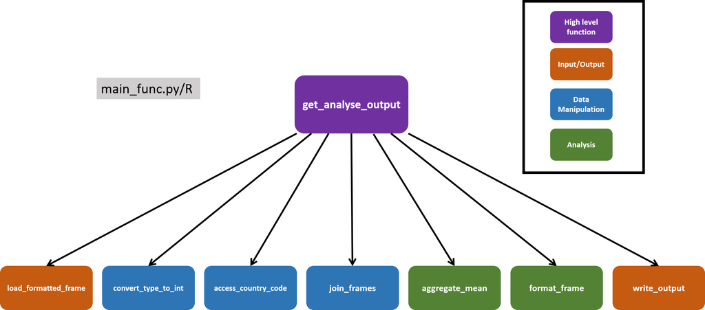

As you can see, a lot of steps are being run by the single `get_analyse_output()` function. It is really important we have this high level function, but we can have more if it makes the structure of our program clearer.

Below we will first look at a new code diagram with a different structure to the previous, then the code it corresponds to.

This is slight overkill for our program at the moment due to it’s small size, but the principle is very useful as our code becomes more complex.

The new structure:

- still has a highest level `get_analyse_output()` function
- contains multiple functions in between the lowest level and the highest
- has middle functions which perform a larger task, grouping smaller tasks together

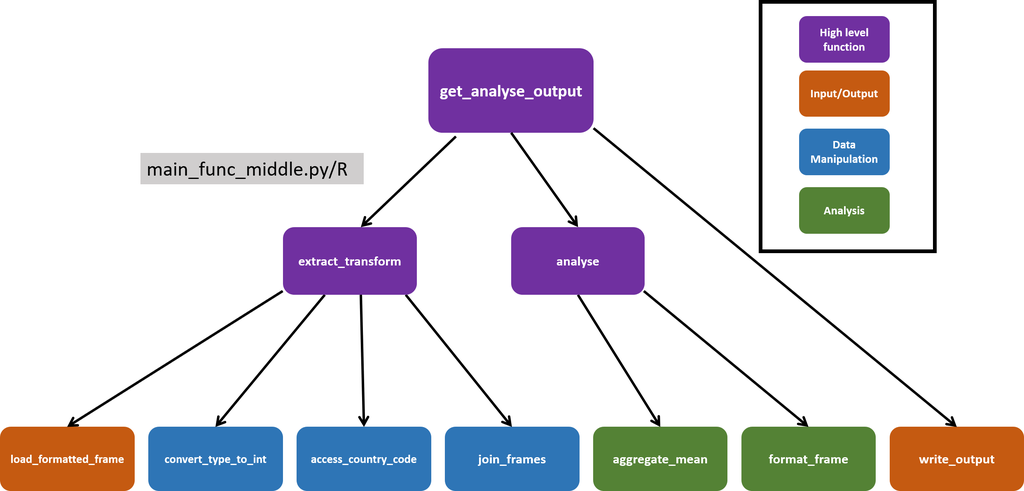

> Note that we have not added an additional higher level function above `write_output()`. This is because we don’t need to have a higher function calling just one lower level function. In addition, we do not always want to write out data out while we test the analysis pipeline.

The benefits of this structure is that we can more easily access the data produced by our pipeline at relevant steps.

- if we want to look at the joined data after cleaning and manipulation we just call the `extract_transform()` function
- to perform a different analysis on the cleaned frame we can write a different `analyse()` function and call that instead within `get_analyse_output()`

### Python New Structure

```python
import pandas as pd
import os


def load_formatted_frame(path_to_data):
    """Read csv and reformat column names"""
    formatted_path = os.path.join(path_to_data)
    # Load the csv from given path
    dataframe = pd.read_csv(formatted_path)

    # Clean the column names, following naming conventions similar to PEP8
    dataframe.columns = dataframe.columns.str.lower()
    dataframe.columns = dataframe.columns.str.replace(" ", "_")

    return dataframe


def access_country_code(dataframe):
    """Function to split combined code columns and remove uncessary columns"""

    dataframe = dataframe.copy()

    dataframe[["country_code", "parent_code"]] = (dataframe["country_and_parent_code"]
                                                .str.split("_", expand=True))

    dataframe_dropped = dataframe.drop(labels=[
                                                "country_and_parent_code",
                                                "parent_code"
                                              ], axis=1)
    return dataframe_dropped



def convert_type_to_int(dataframe, column_name, string_value):
    """Function to convert string to integer column type"""

    dataframe = dataframe.copy()

    dataframe[column_name] = dataframe[column_name].str.replace(string_value, "")

    dataframe[column_name] = dataframe[column_name].astype(int)

    return dataframe


def join_frames(left_dataframe, right_dataframe, left_column, right_column):
    """
    Function to join the required frames on specified columns, dropping
    unrecessary column
    """

    left_dataframe = left_dataframe.copy()
    right_dataframe = right_dataframe.copy()

    combined_frames = left_dataframe.merge(right=right_dataframe,
                                           how="left",
                                           left_on=left_column,
                                           right_on=right_column)

    combined_frames_reduced = combined_frames.drop(labels=[right_column], axis=1)

    return combined_frames_reduced


def aggregate_mean(dataframe, groupby_column, aggregate_column):
    """Function to groupby and calculate the aggregate mean of two columns"""

    dataframe = dataframe.copy()

    # Remove unecessary columns
    subset = dataframe[[groupby_column, aggregate_column]]

    # Perform mean calculation
    statistic = (subset.groupby(groupby_column, as_index=False)
                       .agg({aggregate_column: "mean"}))

    statistic_renamed = statistic.rename(columns={aggregate_column: "mean_" + aggregate_column})

    return statistic_renamed



def format_frame(dataframe, statistic_column):
    """Function to format the dataframe for output"""

    dataframe = dataframe.copy()

    dataframe_sorted = dataframe.sort_values(by=statistic_column,
                                             ascending=False)

    dataframe_sorted[statistic_column] = dataframe_sorted[statistic_column].round(2)

    return dataframe_sorted


def write_output(dataframe, output_filepath):
    """Function to write output statistic in formatted manner"""

    dataframe.to_csv(output_filepath, index=False, sep=",")



def extract_transform(population_filepath, location_filepath):
    """Load the data and convert it to clean joined format for analysis"""

    pop_density = load_formatted_frame(population_filepath)
    locations = load_formatted_frame(location_filepath)


    pop_density_single_code = access_country_code(pop_density)


    pop_density_correct_types = convert_type_to_int(dataframe=pop_density_single_code,
                                                    column_name="country_code",
                                                    string_value="CC")

    locations_correct_types = convert_type_to_int(dataframe=locations,
                                                  column_name="location_id",
                                                  string_value='"')

    population_location = join_frames(left_dataframe=pop_density_correct_types,
                                       right_dataframe=locations_correct_types,
                                       left_column="country_code",
                                       right_column="location_id")

    return population_location


def analyse(full_dataframe, groupby_column, aggregate_column, statistic_column):
    """Function to perform groupby mean of population density and reformat result"""

    full_dataframe = full_dataframe.copy()

    aggreagation = aggregate_mean(dataframe=full_dataframe,
                                  groupby_column=groupby_column,
                                  aggregate_column=aggregate_column)

    formatted_statistic = format_frame(aggreagation, statistic_column=statistic_column)


    return formatted_statistic



def get_analyse_output(population_filepath, location_filepath, output_filepath):
    """
    Access the data, run the analysis of population density means over locations,
    output the data into a csv.
    """

    population_location = extract_transform(population_filepath=population_filepath,
                                            location_filepath=location_filepath)

    formatted_statistic = analyse(full_dataframe=population_location,
                                  groupby_column="sdg_region_name",
                                  aggregate_column="population_density",
                                  statistic_column="mean_population_density")

    write_output(formatted_statistic, output_filepath)



if __name__ == "__main__":
    get_analyse_output(population_filepath="../../data/population_density_2019.csv",
                       location_filepath="../../data/locations.csv",
                       output_filepath="./mean_pop_density.csv")
```

### R New Structure

```r
library(tidyr)
library(dplyr)
library(stringr)
library(readr)


#' Read population data and reformat column names
load_formatted_frame <- function(path_to_data) {
  # Load the population density data 2019
  formatted_path <- file.path(path_to_data)
  dataframe <- readr::read_csv(formatted_path)

  # Clean the column names, following snake_case convention
  colnames(dataframe) <- tolower(colnames(dataframe))
  colnames(dataframe) <- stringr::str_replace_all(colnames(dataframe), pattern = " ", replacement = "_")

  return(dataframe)
}


#' Function to split combined code columns
#' and remove uncessary columns
access_country_code <- function(dataframe) {
  # The country_and_parent_code column needs to
  # be split into two columns without the strings
  dataframe <- tidyr::separate(data = dataframe, col = country_and_parent_code,
                               into = c("country_code", "parent_code"), sep = "_")


  # Remove the  parent_code column, not used in later analysis
  dataframe <- dplyr::select(dataframe, everything(), -parent_code)

  return(dataframe)
}


#' Function to convert string to integer column type
convert_type_to_int <- function(dataframe, column_name, string_value) {

  # Convert country_code to integer by removing extra strings
  # Using dataframe$column_name to get a column won't work when the column name is a variable
  dataframe[column_name] <- stringr::str_remove_all(dataframe[[column_name]], pattern = string_value)

  # Convert type
  dataframe[column_name] <- as.integer(dataframe[[column_name]])

  return(dataframe)
}

#' Join the required frames on specified columns,
#' dropping unecessary columns
join_frames <- function(left_dataframe, right_dataframe, left_column, right_column) {

  # Change location_id to be called country_code for join
  colnames(right_dataframe)[colnames(right_dataframe) == right_column] <- left_column

  combined_frames <- dplyr::left_join(x = left_dataframe,
                                      y = right_dataframe,
                                      by = left_column)

  combined_frames_reduced <- dplyr::select(combined_frames, sdg_region_name, population_density)

  return(combined_frames_reduced)
}


#' Function to groupby and calculate the mean of two columns
aggregate_mean <- function(dataframe, groupby_column, statistic_column) {

  # Perform aggregation and summary

  # Use group_by_ because of variable column name
  region_mean_density_grouped <- group_by_(.data = dataframe, groupby_column)

  # use get() to access column name
  region_mean_density <- dplyr::summarise(.data = region_mean_density_grouped,
                                          "mean_population_density" = mean(get(statistic_column)))

  return(region_mean_density)
}


#' Format the dataframe for output
format_frame <- function(dataframe, statistic_column) {

  # Sort the data for clearer reading, descending order
  dataframe_sorted <- dplyr::arrange(.data = dataframe)

  # Round mean density for clearer reading
  dataframe_sorted[statistic_column] <- round(dataframe_sorted[statistic_column],
                                              digits = 2)

  return(dataframe_sorted)
}

#' write output statistic in formatted manner
write_output <- function(dataframe, output_filepath) {

  readr::write_csv(x = dataframe, path = output_filepath)

}


#' Load the data and convert it to clean joined format for analysis
extract_transform <- function(population_filepath, location_filepath) {

  pop_density <- load_formatted_frame(population_filepath)
  locations <- load_formatted_frame(location_filepath)


  pop_density_single_code <- access_country_code(pop_density)


  pop_density_correct_types <- convert_type_to_int(dataframe = pop_density_single_code,
                                                column_name = "country_code",
                                                string_value = "CC")

  locations_correct_types <- convert_type_to_int(dataframe = locations,
                                              column_name = "location_id",
                                              string_value = '"')

  population_location <- join_frames(left_dataframe = pop_density_correct_types,
                                     right_dataframe = locations_correct_types,
                                     left_column = "country_code",
                                     right_column = "location_id")

  return(population_location)
}

#' Perform groupby mean of population density and reformat result
analyse <- function(full_dataframe, groupby_column, aggregate_column, statistic_column) {

  aggreagation = aggregate_mean(dataframe = full_dataframe,
                                groupby_column = groupby_column,
                                statistic_column = aggregate_column)

  formatted_statistic = format_frame(aggreagation, statistic_column = statistic_column)


  return(formatted_statistic)
}


#' Access the data, run the analysis of population density means over locations,
#' output the data into a csv.
get_analyse_output <- function(population_filepath, location_filepath, output_filepath) {

  population_location = extract_transform(population_filepath = population_filepath,
                                        location_filepath = location_filepath)

  formatted_statistic = analyse(full_dataframe = population_location,
                                groupby_column = "sdg_region_name",
                                aggregate_column = "population_density",
                                statistic_column = "mean_population_density")

  write_output(formatted_statistic, output_filepath)

}




get_analyse_output(population_filepath="../../data/population_density_2019.csv",
                   location_filepath="../../data/locations.csv",
                   output_filepath="./mean_pop_density.csv")
```

## 3.7 Interaction

“Who will need to access this part of the program?” is a useful question to think about when structuring your code.

As the main developer you will likely be accessing the whole code base, every function.

To run the program a user only needs to interact with a small part of the program. The part of the program a user will be interacting with is called the “application programming interface”, API. Other areas of the code can be seen, but rarely used by the user.

Parts of your code can be “hidden” from the user. The end user does not need to understand every line of code or function. The user only needs to run the program.

By structuring the code properly, it is possible to “hide” the private parts from users - they do not need to understand or access the inner workings of every function - they just need to run the program.

In our code the API part would be the `get_analyse_output()` function.

Separating public facing and lower level functions improves clarity and usability. All code should be as clear as possible whether it is the API or lower to help with future development.

Having this distinction allows us to test the code at the correct levels.

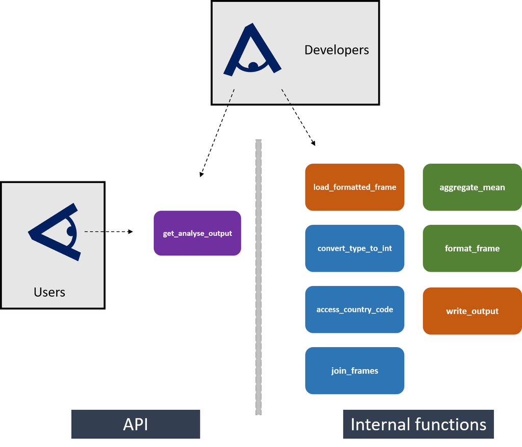

By having a hierarchy of functions with distinctions about what the API is can make the code simpler. Structuring the code well makes it easier to run, test and fix for developers and users.

This concept becomes more important in:

- software products with non-technical users
- object-oriented programming, using public interfaces

Ideally, a user does not need to open any code files to run analysis. Instead, the user can work with a graphical user interface (GUI) or command line interface. Parameters such as the input data file paths and output paths are written in a separate file or by the user in the interface.

“What will the end product of my analysis pipeline be?” is an important question to consider when structuring your project.

# 4 Functions to Modules

Earlier in this course a scenario was introduced explaining that a single script can grow large and become difficult to maintain.

Although adding structure with functions makes our code better, it can make it longer. Larger code files are difficult to maintain and understand.

We can make our code even clearer and better-structured by moving the functions in our code into different files. By grouping related functions together into different files it will be easier to look up different parts of our code. We no longer need to scroll through thousands of lines of code, we just navigate to the relevant file.

When we move functions (or other objects) into different files, they then need to be imported back into the file we are using those functions in.

There are some key differences between R and Python in this area. When we move code into different files:

- the code in files are imported as “modules” in Python
- the code in files are “sourced” into the R environment

Before structuring code in different files, we need to discuss how to structure our directory properly to help us with this.

## 4.1 Project Structure

Now we are moving beyond working with just one script we need to consider our project, files, folders/directories and paths.

A key part of building a reproducible collection of code is making the project folder simple to understand, navigate and work with.

There is no single folder structure that is perfect for all analysis, however, there are good minimum requirements and guiding principles.

The situation to avoid is having all your data, course code, notebooks and documentation in the same location. This is confusing to anyone else looking in, and makes it harder for your project to be extended.

In this section we will outline basic components of project structure, their relevance to this course, and point to good resources for deciding your own approach.

### 4.1.1 Guiding Principles

The main principles are

- the complexity of the folder structure should be in line with the size/complexity of the project
  - smaller analysis should a have simpler folder structure
  - larger projects require more depth of structure (more sections, more folders dividing areas)
- different file types should generally be separated, for example keep the .py|R files together, the CSVs together, the Jupyter notebooks and R Markdowns in one place
- what the end product of the project is should impact the structure. If the code is to become a package, an appropriate structure should be used.

### 4.1.2 Minimum requirements

A directory structure for analysis should separate the:

- data used to analyse
- course code to perform analysis
- report generation / notebook files, figures and images
- documentation
- READMEs, licenses, package requirements

In addition, relevant version control folders/files will be present (not covered in this course) - .git folder, .gitignore file.

How this is done may depend on your team, language, and specific use case.

An example folder structure for our project is shown below, this is a minimum and could be extended.

```python
population_density_analysis
|   LICENSE.txt
|   README.md
|   requirements.txt
|
+---data
|   +---processed
|   |       mean_pop_density.csv
|   |
|   \---raw
|           locations.csv
|           population_density_2019.csv
|
+---docs
|       documentation.txt
|       user_guide.html
|
+---reports
|   |   population_analysis_report.html
|   |   population_analysis_report.rmd
|   |
|   \---figures
|           graph.png
|
\---src
        main_func (to be broken up).py
```

Note: `/src/` stands for “source” - referring to your source code, the files your program is written with.

### 4.1.3 Additional content

There are other folders and considerations to structure your project beyond the minimum.

You may want to have separate folders for:

- different parts of your code within the `/src/` folder
- references such as data dictionaries and user manuals
- Further divisions of your `/data/` folder
- models or other output products produced
- notebooks for enhanced documentations and examples
- A way to produce example data
- environment building

In R, consider using a predefined project structure using the `.Rproj` method, which generates a structure for you:

- [This a blog guiding you on its usage](https://nicercode.github.io/blog/2013-04-05-projects/)
- [Here is a article from RStudio showing how to use projects within the IDE](https://support.rstudio.com/hc/en-us/articles/200526207-Using-Projects)

In Python there are alternative resources for data science project structure:

- [Cookiecutter outlines important considerations for Python projects, with a way to download example structures](https://drivendata.github.io/cookiecutter-data-science/#cookiecutter-data-science)

For both Python and R there is a project structure designed by the Government Digital Service for data science projects.

- [Cookiecutter project structure for data science in government](https://github.com/ukgovdatascience/govcookiecutter) The repository is designed to use best practices. It uses pre-populated templates to encourage collaboration. In addition it prevents the committing of passwords and rendered notebooks.

## 4.2 Using Separate Files

Now that we are aware of good project folder structure, we can discuss separating our big full code file into more logical smaller files.

This section will focus on the code contained within the `/src/` folder shown in the last section.

Group functions with similar purpose together, such as `data cleaning`, `loading`, `modelling`. Make each file/module as focussed as possible to make it easy to find any required function.

To move the functions between files there are four main steps that need to be taken:

- move the code between files (copy and paste)
- check the new file can access all the code it needs
- import the new file / function into the relevant files in the code base
- check this has not affected how our code runs (test it hasn’t changed)

Moving code between files when a script already exists is a task that can be avoided by designing your project files in a useful way when starting to write your code. Any new analysis should make use of existing modules that you have created.

Note: in some other people’s code, particularly R code, you may see many files with only one function in each file. This is to be avoided as it does not help group code making it easier to work with. Generally, avoid files containing all the functions of a program, and avoid having many files each containing one function. For further information about this, with reference to R code package conventions have a look at the [“R Packages” book](https://r-pkgs.org/r.html#code-organising).

### 4.2.1 Moving Code

In this section we will learn how to move functions between files.

In the earlier part of the course “Function Inputs” we discussed why it is important that variables are only accessed through function inputs and outputs. This principle is even more important when moving code between files.

We are first going to make a new file called `input_output.py|R`. This file is going to contain all the code we need for loading and exporting our data frames. It is good practice to group related functions into the same file - especially around data access.

In addition, we are going to rename our original script to `main.py|R`. This is the file that will run all our code.

Within the `input_output.py|R` file we are going to put the following functions, removing them from `main.py|R`:

- `load_formatted_frame()`
- `write_output()`

Our files will now appear as below. Note, they will not currently run.

#### Python

##### main.py

File contains most of the code used to run the program.

```python
import pandas as pd


def access_country_code(dataframe):
    """Function to split combined code columns and remove uncessary columns"""

    dataframe = dataframe.copy()

    dataframe[["country_code", "parent_code"]] = (dataframe["country_and_parent_code"]
                                                .str.split("_", expand=True))

    dataframe_dropped = dataframe.drop(labels=[
                                                "country_and_parent_code",
                                                "parent_code"
                                              ], axis=1)
    return dataframe_dropped



def convert_type_to_int(dataframe, column_name, string_value):
    """Function to convert string to integer column type"""

    dataframe = dataframe.copy()

    dataframe[column_name] = dataframe[column_name].str.replace(string_value, "")

    dataframe[column_name] = dataframe[column_name].astype(int)

    return dataframe


def join_frames(left_dataframe, right_dataframe, left_column, right_column):
    """
    Function to join the required frames on specified columns, dropping
    unrecessary column
    """

    left_dataframe = left_dataframe.copy()
    right_dataframe = right_dataframe.copy()

    combined_frames = left_dataframe.merge(right=right_dataframe,
                                           how="left",
                                           left_on=left_column,
                                           right_on=right_column)

    combined_frames_reduced = combined_frames.drop(labels=[right_column], axis=1)

    return combined_frames_reduced


def aggregate_mean(dataframe, groupby_column, aggregate_column):
    """Function to groupby and calculate the aggregate mean of two columns"""

    dataframe = dataframe.copy()

    # Remove unecessary columns
    subset = dataframe[[groupby_column, aggregate_column]]

    # Perform mean calculation
    statistic = (subset.groupby(groupby_column, as_index=False)
                       .agg({aggregate_column: "mean"}))

    statistic_renamed = statistic.rename(columns={aggregate_column: "mean_" + aggregate_column})

    return statistic_renamed



def format_frame(dataframe, statistic_column):
    """Function to format the dataframe for output"""

    dataframe = dataframe.copy()

    dataframe_sorted = dataframe.sort_values(by=statistic_column,
                                             ascending=False)

    dataframe_sorted[statistic_column] = dataframe_sorted[statistic_column].round(2)

    return dataframe_sorted





def get_analyse_output():
    """
    Access the data, run the analysis of population density means over locations,
    output the data into a csv.
    """

    pop_density = load_formatted_frame("../../data/population_density_2019.csv")
    locations = load_formatted_frame("../../data/locations.csv")


    pop_density_single_code = access_country_code(pop_density)


    pop_density_correct_types = convert_type_to_int(dataframe=pop_density_single_code,
                                                    column_name="country_code",
                                                    string_value="CC")

    locations_correct_types = convert_type_to_int(dataframe=locations,
                                                  column_name="location_id",
                                                  string_value='"')

    population_location = join_frames(left_dataframe=pop_density_correct_types,
                                       right_dataframe=locations_correct_types,
                                       left_column="country_code",
                                       right_column="location_id")

    aggreagation = aggregate_mean(dataframe=population_location,
                                  groupby_column="sdg_region_name",
                                  aggregate_column="population_density")

    formatted_statistic = format_frame(aggreagation, "mean_population_density")

    write_output(formatted_statistic, output_filepath="./mean_pop_density.csv")



if __name__ == "__main__":
    get_analyse_output()
```

##### input_output.py

File contains the functions used for input and output operations.

```python
import pandas as pd
import os


def load_formatted_frame(path_to_data):
    """Read csv and reformat column names"""
    formatted_path = os.path.join(path_to_data)
    # Load the csv from given path
    dataframe = pd.read_csv(formatted_path)

    # Clean the column names, following naming conventions similar to PEP8
    dataframe.columns = dataframe.columns.str.lower()
    dataframe.columns = dataframe.columns.str.replace(" ", "_")

    return dataframe


def write_output(dataframe, output_filepath):
    """Function to write output statistic in formatted manner"""

    dataframe.to_csv(output_filepath, index=False, sep=",")
```

#### R

##### main.r

File contains most of the code used to run the program.

```r
library(tidyr)
library(dplyr)
library(stringr)
library(readr)

#' Split combined code columns
#' and remove uncessary columns
access_country_code <- function(dataframe) {
  # The country_and_parent_code column needs to
  # be split into two columns without the strings
  dataframe <- tidyr::separate(data = dataframe, col = country_and_parent_code,
                               into = c("country_code", "parent_code"), sep = "_")


  # Remove the  parent_code column, not used in later analysis
  dataframe <- dplyr::select(dataframe, everything(), -parent_code)

  return(dataframe)
}


#' Function to convert string to integer column type
convert_type_to_int <- function(dataframe, column_name, string_value) {

  # Convert country_code to integer by removing extra strings
  # Using dataframe$column_name to get a column won't work when the column name is a variable
  dataframe[column_name] <- stringr::str_remove_all(dataframe[[column_name]], pattern = string_value)

  # Convert type
  dataframe[column_name] <- as.integer(dataframe[[column_name]])

  return(dataframe)
}

#' Join the required frames on specified columns,
#' dropping unecessary columns
join_frames <- function(left_dataframe, right_dataframe, left_column, right_column) {

  # Change location_id to be called country_code for join
  colnames(right_dataframe)[colnames(right_dataframe) == right_column] <- left_column

  combined_frames <- dplyr::left_join(x = left_dataframe,
                                      y = right_dataframe,
                                      by = left_column)

  combined_frames_reduced <- dplyr::select(combined_frames, sdg_region_name, population_density)

  return(combined_frames_reduced)
}


#' Function to groupby and calculate the mean of two columns
aggregate_mean <- function(dataframe, groupby_column, statistic_column) {

  # Perform aggregation and summary

  # Use group_by_ because of variable column name
  region_mean_density_grouped <- group_by_(.data = dataframe, groupby_column)

  # use get() to access column name
  region_mean_density <- dplyr::summarise(.data = region_mean_density_grouped,
                                          "mean_population_density" = mean(get(statistic_column)))

  return(region_mean_density)
}


#' Format the dataframe for output
format_frame <- function(dataframe, statistic_column) {

  # Sort the data for clearer reading, descending order
  dataframe_sorted <- dplyr::arrange(.data = dataframe)

  # Round mean density for clearer reading
  dataframe_sorted[statistic_column] <- round(dataframe_sorted[statistic_column],
                                              digits = 2)

  return(dataframe_sorted)
}


#' Access the data, run the analysis of population density means over locations,
#' output the data into a csv.
get_analyse_output <- function() {

  pop_density <- load_formatted_frame("../../../data/population_density_2019.csv")
  locations <- load_formatted_frame("../../../data/locations.csv")


  pop_density_single_code <- access_country_code(pop_density)


  pop_density_correct_types <- convert_type_to_int(dataframe = pop_density_single_code,
                                                   column_name = "country_code",
                                                   string_value = "CC")

  locations_correct_types <- convert_type_to_int(dataframe = locations,
                                                 column_name = "location_id",
                                                 string_value = '"')

  population_location <- join_frames(pop_density_correct_types,
                                     locations_correct_types,
                                     left_column = "country_code",
                                     right_column = "location_id")

  aggreagation <- aggregate_mean(dataframe = population_location,
                                 groupby_column = "sdg_region_name",
                                 statistic_column = "population_density")

  formatted_statistic <- format_frame(aggreagation, "mean_population_density")

  write_output(formatted_statistic, "./mean_pop_density.csv")

}


## Run the main function created

get_analyse_output()
```

##### input_output.r

File contains the functions used for input and output operations.

```r
library(readr)

#' Read population data and reformat column names
load_formatted_frame <- function(path_to_data) {
    # Load the population density data 2019
    formatted_path <- file.path(path_to_data)
    dataframe <- readr::read_csv(formatted_path)

    # Clean the column names, following snake_case convention
    colnames(dataframe) <- tolower(colnames(dataframe))
    colnames(dataframe) <- stringr::str_replace_all(colnames(dataframe), pattern = " ", replacement = "_")

    return(dataframe)
}



#' write output statistic in formatted manner
write_output <- function(dataframe, output_filepath) {

    readr::write_csv(x = dataframe, path = output_filepath)

}
```

### 4.2.2 Loading Code Between Files

The code shown above will not run because the `main.py|R` code cannot access the functions contained within `input_output.py|R`.

For a program to access code in another location the functions need to be loaded into that program explicitly.

- in Python this would be called “importing a module”
- in R this would be called “sourcing function(s)”

We load the code from one file into the another allowing our code to access the contents of the loaded file.

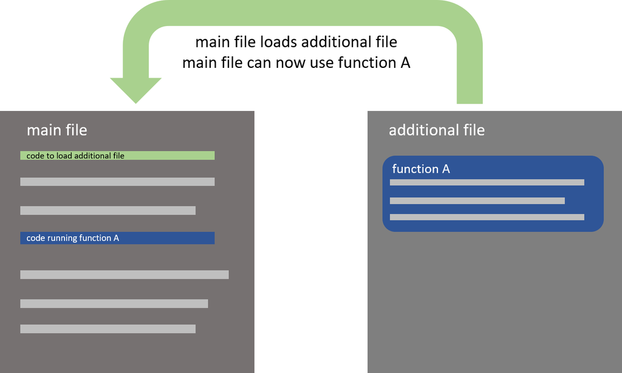

Loading a file puts the objects within into the scope of our program.

If we load a file’s code in the global scope of our program, then the file’s contents will be accessible anywhere in the program. If we load the file in a specific local scope it will only be accessible in that local area.

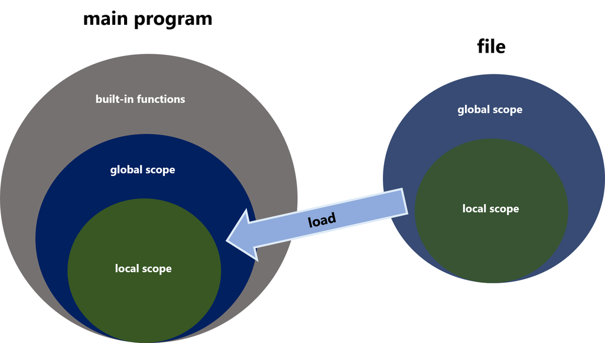

#### Python

In Python we load our own modules (files) in a very similar way to how we load third party packages such as `pandas`, `matplotlib` or `numpy`.

Python will search a range of locations to find the module we have requested. For now we will assume that all modules are in the same directory as the file we are loading them from.

When a module is imported into a file it becomes an object. The contents of the module can be accessed from this module object.

To import a module (file)

```python
import input_output
```

In order to use a function from the module, we prepend the function name with the module name; this would also work for classes.

```python
import input_output

dataframe = input_output.load_formatted_frame(path_to_data="./data.csv")
```

This method makes it clear from which module each function is being used.

This means we will need to change our existing `main.py` file to use the correct module name and function.

Alternatively, if we only need one specific function from a module, we can import the function on its own.

```python
from input_output import load_formatted_frame

dataframe = load_formatted_frame(path_to_data="./data.csv")
```

It is good practice to avoid loading in specific functions where there may already be functions in the program with the same or similar names to prevent overwriting of functions or confusion around names.

Below is the `main.py` file which imports the `input_output` module. The function calls in `main` have been changed to refer to the `input_output` module. Read through the code to see the changes.

By convention modules are loaded at the top of a file. This makes it clear what modules are used in the code and ensures all parts of the code that need the module can access it.

```python
import pandas as pd

import input_output


def access_country_code(dataframe):
    """Function to split combined code columns and remove uncessary columns"""

    dataframe = dataframe.copy()

    dataframe[["country_code", "parent_code"]] = (dataframe["country_and_parent_code"]
                                                .str.split("_", expand=True))

    dataframe_dropped = dataframe.drop(labels=[
                                                "country_and_parent_code",
                                                "parent_code"
                                              ], axis=1)
    return dataframe_dropped



def convert_type_to_int(dataframe, column_name, string_value):
    """Function to convert string to integer column type"""

    dataframe = dataframe.copy()

    dataframe[column_name] = dataframe[column_name].str.replace(string_value, "")

    dataframe[column_name] = dataframe[column_name].astype(int)

    return dataframe


def join_frames(left_dataframe, right_dataframe, left_column, right_column):
    """
    Function to join the required frames on specified columns, dropping
    unrecessary column
    """

    left_dataframe = left_dataframe.copy()
    right_dataframe = right_dataframe.copy()

    combined_frames = left_dataframe.merge(right=right_dataframe,
                                           how="left",
                                           left_on=left_column,
                                           right_on=right_column)

    combined_frames_reduced = combined_frames.drop(labels=[right_column], axis=1)

    return combined_frames_reduced


def aggregate_mean(dataframe, groupby_column, aggregate_column):
    """Function to groupby and calculate the aggregate mean of two columns"""

    dataframe = dataframe.copy()

    # Remove unecessary columns
    subset = dataframe[[groupby_column, aggregate_column]]

    # Perform mean calculation
    statistic = (subset.groupby(groupby_column, as_index=False)
                       .agg({aggregate_column: "mean"}))

    statistic_renamed = statistic.rename(columns={aggregate_column: "mean_" + aggregate_column})

    return statistic_renamed



def format_frame(dataframe, statistic_column):
    """Function to format the dataframe for output"""

    dataframe = dataframe.copy()

    dataframe_sorted = dataframe.sort_values(by=statistic_column,
                                             ascending=False)

    dataframe_sorted[statistic_column] = dataframe_sorted[statistic_column].round(2)

    return dataframe_sorted





def get_analyse_output():
    """
    Access the data, run the analysis of population density means over locations,
    output the data into a csv.
    """
    # Added the module name here
    pop_density = input_output.load_formatted_frame("../../../data/population_density_2019.csv")
    locations = input_output.load_formatted_frame("../../../data/locations.csv")


    pop_density_single_code = access_country_code(pop_density)


    pop_density_correct_types = convert_type_to_int(dataframe=pop_density_single_code,
                                                    column_name="country_code",
                                                    string_value="CC")

    locations_correct_types = convert_type_to_int(dataframe=locations,
                                                  column_name="location_id",
                                                  string_value='"')

    population_location = join_frames(left_dataframe=pop_density_correct_types,
                                       right_dataframe=locations_correct_types,
                                       left_column="country_code",
                                       right_column="location_id")

    aggreagation = aggregate_mean(dataframe=population_location,
                                  groupby_column="sdg_region_name",
                                  aggregate_column="population_density")

    formatted_statistic = format_frame(aggreagation, "mean_population_density")

    # Added the module name here
    input_output.write_output(formatted_statistic, output_filepath="./mean_pop_density.csv")



if __name__ == "__main__":
    get_analyse_output()
```

If we want to debug or manually test our functions within `input_output` we can add the following line of code to the end of our script. The code within this block will only run if we run the `input_output.py` file itself, not the `main.py` file.

```python
if __name__ == "__main__":
  # code to debug and test
```

As you look at others’ code you will see a variety of ways to import modules. Below we discuss two frequent conventions.

> You can change the name of an imported module for ease of use by using the `as` keyword.

This is often seen with common third-party packages - such as `pandas` or `numpy` but will work for any module.

```python
import pandas as pd
import numpy as np
```

This does not change the functionality of the module at all, just changes the name.

> All objects in a module can be imported to the global scope at once, this should be avoided.

The below code is being shown to make you aware of what can be done, but should be avoided.

Instead of importing the module and then specific functions from within - or using the module itself all functions within can be imported. This is done using the `*` operator. This signifies “all”.

The below code would make all the functions in `input_output` available to use in the global scope.

```python
from input_output import *

population = load_formatted_frame("path_to_population")
```

This may seem useful, but it will cause us to overwrite functions of the same name, and make it unclear from which module each function came from. It is not clear in the example above that `load_formatted_frame()` comes from `input_output`. For large projects this will cause issues in readability and bug fixing.

#### R

In R there is a distinction between loading in code from source files and loading in packages.

To load functions into an R program you need to first put those functions into a `.R` file.

Within the file containing the program you want to run, you “source” the file containing the functions. This loads the functions into the program’s global scope.

To source a file use the `source()` function.

Within the `source()` function give the file path of the `.R` file you want to source.

```r
source("path to R file")
```

For our purposes at the top of the `main.R` file we would write:

```r
source("./input_output.R")
```

to access the functions within `input_output.R`.

By convention files are loaded at the top of a file. This makes it clear what files are used in the code and ensures all parts of the code that need the objects in the file can access them.

The sourcing of a file will by default load in all the contents of that file - not just functions. For this reason, it is important to keep the files containing your functions clear of other unnecessary objects such as unnecessary variables.

The `main.R` file will then look like the below script, allowing us to access the functions from `input_output.R`.

```r
library(tidyr)
library(dplyr)
library(stringr)
library(readr)

source("input_output.r")

#' Function to split combined code columns
#' and remove uncessary columns
access_country_code <- function(dataframe) {
  # The country_and_parent_code column needs to
  # be split into two columns without the strings
  dataframe <- tidyr::separate(data = dataframe, col = country_and_parent_code,
                               into = c("country_code", "parent_code"), sep = "_")


  # Remove the  parent_code column, not used in later analysis
  dataframe <- dplyr::select(dataframe, everything(), -parent_code)

  return(dataframe)
}


#' Function to convert string to integer column type
convert_type_to_int <- function(dataframe, column_name, string_value) {

  # Convert country_code to integer by removing extra strings
  # Using dataframe$column_name to get a column won't work when the column name is a variable
  dataframe[column_name] <- stringr::str_remove_all(dataframe[[column_name]], pattern = string_value)

  # Convert type
  dataframe[column_name] <- as.integer(dataframe[[column_name]])

  return(dataframe)
}

#' Join the required frames on specified columns,
#' dropping unecessary columns
join_frames <- function(left_dataframe, right_dataframe, left_column, right_column) {

  # Change location_id to be called country_code for join
  colnames(right_dataframe)[colnames(right_dataframe) == right_column] <- left_column

  combined_frames <- dplyr::left_join(x = left_dataframe,
                                      y = right_dataframe,
                                      by = left_column)

  combined_frames_reduced <- dplyr::select_(combined_frames, left_column)

  return(combined_frames_reduced)
}


#' Function to groupby and calculate the mean of two columns
aggregate_mean <- function(dataframe, groupby_column, statistic_column) {

  # Perform aggregation and summary

  # Use group_by_ because of variable column name
  region_mean_density_grouped <- group_by_(.data = dataframe, groupby_column)

  # use get() to access column name
  region_mean_density <- dplyr::summarise(.data = region_mean_density_grouped,
                                          "mean_population_density" = mean(get(statistic_column)))

  return(region_mean_density)
}


#' Format the dataframe for output
format_frame <- function(dataframe, statistic_column) {

  # Sort the data for clearer reading, descending order
  dataframe_sorted <- dplyr::arrange(.data = dataframe)

  # Round mean density for clearer reading
  dataframe_sorted[statistic_column] <- round(dataframe_sorted[statistic_column],
                                              digits = 2)

  return(dataframe_sorted)
}


#' Access the data, run the analysis of population density means over locations,
#' output the data into a csv.
get_analyse_output <- function() {

  pop_density <- load_formatted_frame("../../../data/population_density_2019.csv")
  locations <- load_formatted_frame("../../../data/locations.csv")


  pop_density_single_code <- access_country_code(pop_density)


  pop_density_correct_types <- convert_type_to_int(dataframe = pop_density_single_code,
                                                   column_name = "country_code",
                                                   string_value = "CC")

  locations_correct_types <- convert_type_to_int(dataframe = locations,
                                                 column_name = "location_id",
                                                 string_value = '"')

  population_location <- join_frames(pop_density_correct_types,
                                     locations_correct_types,
                                     left_column = "country_code",
                                     right_column = "location_id")

  aggreagation <- aggregate_mean(dataframe = population_location,
                                 groupby_column = "sdg_region_name",
                                 statistic_column = "population_density")

  formatted_statistic <- format_frame(aggreagation, "mean_population_density")

  write_output(formatted_statistic, "./mean_pop_density.csv")

}


## Run the main function created

get_analyse_output()
```

## 4.3 Exercises

These exercises will help you practice splitting code into different files and loading them back into the `main.py|R` script.

### Exercise 1

Create a new file in the `example_code/modules/exercises/start/` folder called `analysis.py|R`.

Put the following functions within the new file:

- `aggregate_mean()`
- `format_frame()`

Change the code in `main.py|R` such that the file loads the relevant functions and runs the whole analysis.

### Exercise 2

Create a new file in the `example_code/modules/exercises/start/` folder called `manipulation.py|R`.

Put the following functions within the new file:

- `convert_type_to_int()`
- `access_country_code()`
- `join_frames()`

Change the code in `main.py|R` such that the file loads the relevant functions and runs the whole analysis.

### Answers

**Click for Python Answer**

##### analysis.py

```python
import pandas as pd


def aggregate_mean(dataframe, groupby_column, aggregate_column):
    """Function to groupby and calculate the aggregate mean of two columns"""

    dataframe = dataframe.copy()

    # Remove unecessary columns
    subset = dataframe[[groupby_column, aggregate_column]]

    # Perform mean calculation
    statistic = (subset.groupby(groupby_column, as_index=False)
                       .agg({aggregate_column: "mean"}))

    statistic_renamed = statistic.rename(columns={aggregate_column: "mean_" + aggregate_column})

    return statistic_renamed



def format_frame(dataframe, statistic_column):
    """Function to format the dataframe for output"""

    dataframe = dataframe.copy()

    dataframe_sorted = dataframe.sort_values(by=statistic_column,
                                             ascending=False)

    dataframe_sorted[statistic_column] = dataframe_sorted[statistic_column].round(2)

    return dataframe_sorted
```

##### manipulation.py

```python
import pandas as pd

def access_country_code(dataframe):
    """Function to split combined code columns and remove uncessary columns"""

    dataframe = dataframe.copy()

    dataframe[["country_code", "parent_code"]] = (dataframe["country_and_parent_code"]
                                                .str.split("_", expand=True))

    dataframe_dropped = dataframe.drop(labels=[
                                                "country_and_parent_code",
                                                "parent_code"
                                              ], axis=1)
    return dataframe_dropped



def convert_type_to_int(dataframe, column_name, string_value):
    """Function to convert string to integer column type"""

    dataframe = dataframe.copy()

    dataframe[column_name] = dataframe[column_name].str.replace(string_value, "")

    dataframe[column_name] = dataframe[column_name].astype(int)

    return dataframe


def join_frames(left_dataframe, right_dataframe, left_column, right_column):
    """
    Function to join the required frames on specified columns, dropping
    unrecessary column
    """

    left_dataframe = left_dataframe.copy()
    right_dataframe = right_dataframe.copy()

    combined_frames = left_dataframe.merge(right=right_dataframe,
                                           how="left",
                                           left_on=left_column,
                                           right_on=right_column)

    combined_frames_reduced = combined_frames.drop(labels=[right_column], axis=1)

    return combined_frames_reduced
```

##### main.py

```python
import pandas as pd

# Import our required modules
import input_output
import analysis
import manipulation





def get_analyse_output():
    """
    Access the data, run the analysis of population density means over locations,
    output the data into a csv.
    """

    pop_density = input_output.load_formatted_frame("../../../../data/population_density_2019.csv")
    locations = input_output.load_formatted_frame("../../../../data/locations.csv")


    # Added module names below
    pop_density_single_code = manipulation.access_country_code(pop_density)


    pop_density_correct_types = manipulation.convert_type_to_int(dataframe=pop_density_single_code,
                                                                 column_name="country_code",
                                                                 string_value="CC")

    locations_correct_types = manipulation.convert_type_to_int(dataframe=locations,
                                                               column_name="location_id",
                                                               string_value='"')

    population_location = manipulation.join_frames(left_dataframe=pop_density_correct_types,
                                                   right_dataframe=locations_correct_types,
                                                   left_column="country_code",
                                                   right_column="location_id")

    # Added module name here
    aggreagation = analysis.aggregate_mean(dataframe=population_location,
                                           groupby_column="sdg_region_name",
                                           aggregate_column="population_density")

    formatted_statistic = analysis.format_frame(aggreagation, "mean_population_density")


    input_output.write_output(formatted_statistic, output_filepath="./mean_pop_density.csv")



if __name__ == "__main__":
    get_analyse_output()
```

**Click for R Answer**

##### analysis.r

```r
#' Function to groupby and calculate the mean of two columns
aggregate_mean <- function(dataframe, groupby_column, statistic_column) {

  # Perform aggregation and summary

  # Use group_by_ because of variable column name
  region_mean_density_grouped <- group_by_(.data = dataframe, groupby_column)

  # use get() to access column name
  region_mean_density <- dplyr::summarise(.data = region_mean_density_grouped,
                                          "mean_population_density" = mean(get(statistic_column)))

  return(region_mean_density)
}


#' Format the dataframe for output
format_frame <- function(dataframe, statistic_column) {

  # Sort the data for clearer reading, descending order
  dataframe_sorted <- dplyr::arrange(.data = dataframe)

  # Round mean density for clearer reading
  dataframe_sorted[statistic_column] <- round(dataframe_sorted[statistic_column],
                                              digits = 2)

  return(dataframe_sorted)
}
```

##### manipulation.r

```r
#' Function to split combined code columns
#' and remove uncessary columns
access_country_code <- function(dataframe) {
  # The country_and_parent_code column needs to
  # be split into two columns without the strings
  dataframe <- tidyr::separate(data = dataframe, col = country_and_parent_code,
                               into = c("country_code", "parent_code"), sep = "_")


  # Remove the  parent_code column, not used in later analysis
  dataframe <- dplyr::select(dataframe, everything(), -parent_code)

  return(dataframe)
}


#' Function to convert string to integer column type
convert_type_to_int <- function(dataframe, column_name, string_value) {

  # Convert country_code to integer by removing extra strings
  # Using dataframe$column_name to get a column won't work when the column name is a variable
  dataframe[column_name] <- stringr::str_remove_all(dataframe[[column_name]], pattern = string_value)

  # Convert type
  dataframe[column_name] <- as.integer(dataframe[[column_name]])

  return(dataframe)
}

#' Join the required frames on specified columns,
#' dropping unecessary columns
join_frames <- function(left_dataframe, right_dataframe, left_column, right_column) {

  # Change location_id to be called country_code for join
  colnames(right_dataframe)[colnames(right_dataframe) == right_column] <- left_column

  combined_frames <- dplyr::left_join(x = left_dataframe,
                                      y = right_dataframe,
                                      by = left_column)

  combined_frames_reduced <- dplyr::select(combined_frames, sdg_region_name, population_density)

  return(combined_frames_reduced)
}
```

##### main.r

```r
library(tidyr)
library(dplyr)
library(stringr)
library(readr)

source("input_output.r")
source("analysis.r")
source("manipulation.r")




#' Access the data, run the analysis of population density means over locations,
#' output the data into a csv.
get_analyse_output <- function() {

  pop_density <- load_formatted_frame("../../../../data/population_density_2019.csv")
  locations <- load_formatted_frame("../../../../data/locations.csv")


  pop_density_single_code <- access_country_code(pop_density)


  pop_density_correct_types <- convert_type_to_int(dataframe = pop_density_single_code,
                                                   column_name = "country_code",
                                                   string_value = "CC")

  locations_correct_types <- convert_type_to_int(dataframe = locations,
                                                 column_name = "location_id",
                                                 string_value = '"')

  population_location <- join_frames(pop_density_correct_types,
                                     locations_correct_types,
                                     left_column = "country_code",
                                     right_column = "location_id")

  aggreagation <- aggregate_mean(dataframe = population_location,
                                 groupby_column = "sdg_region_name",
                                 statistic_column = "population_density")

  formatted_statistic <- format_frame(aggreagation, "mean_population_density")

  write_output(formatted_statistic, "./mean_pop_density.csv")

}


## Run the main function created

get_analyse_output()
```

# 5 Case Study

Our analysis pipeline for average population density is near complete now.

So far, we have been working on one single data set. Now however we have been given access to the population density values for a range of years in different CSV files.

You now need to add to and improve the code and files to meet new requirements. The code to change can be found in `example_code/case_study/initial/`.

This is not the exact methodology for calculating the mean population density in a region - however by completing this case study you will gain experience building a pipeline for analysis.

## 5.1 Tasks

The below tasks are intended to reinforce the content covered in this course.

Tasks 1-4 are similar to exercises already covered.

Tasks 5 and 6 will require more thought and working with data frames and your chosen languages. You may need to do some research in your chosen language/package to complete them.

Answers to all of the tasks combined are given below, and the full code is contained within `example_code/case_study/answers/`.

### 5.1.1 Task 1

In order to be able to perform the analysis across different years, we need to access different files:

- add new parameters to the function `get_analyse_output()` in `main.py|R`
- the first parameter should be the file path to the population density data CSV: `pop_density_filepath`
- the second parameter should be the file path to the `locations.csv` data: `location_filepath`

Test that your refactoring of the code produces the same result by running the program with the original data sets.

Test that your refactoring of the code works for other data sets by using the `2018` data.

### 5.1.2 Task 2

As we build analysis on top of the code we have already written, the `get_analyse_output()` will not be the highest level function:

- change the `get_analyse_output()` function to return the calculated final data frame `formatted_statistic`.
- change the function so it takes a parameter `output_filepath` of the output path of the reslting data frame.
  - if this value given is `False/FALSE` do not write out the data frame to a file

Test this new parameter by running it with a file path and with `False/FALSE`.

### 5.1.3 Task 3

We will be joining the data at the end of our process, this means we will be performing multiple joins in the analysis:

- create a new file in the directory called `joins.py|R`
- move the function `join_frames()` from `manipulation.py|R` to `join.py|R`

Ensure your code still works at this stage.

### 5.1.4 Task 4

If we are going to combine all our data, we will need to change how it is represented:

- write a function that changes a column name of a given column to a different string. Call it `column_name_year()` and put it in `manipulation.py|R`
  - the first parameter is the data frame to be changed `dataframe`
  - the second is the column name to be changed `original_column`
  - the third is the new column name `new_column`

Test this function on a data frame.

### 5.1.5 Task 5

Once we have created a new data frame for each year we will need to combine the data for each region into one data frame:

- write a new function `join_years()` in `joins.py|R`
  - this function will perform a join on all the frames given to it on the same column name
  - the function takes as a parameter `dataframes`, a list containing the data frames to be joined
  - the function takes as a parameter the name of the column all frames are to be joined on `join_column`
  - the function performs an inner join on all the data frames together on the given column and returns this complete data frame of multiple years

We need to bring all our new functions together to perform the final analysis:

Be sure to run the whole process in one command to check that it produces the output expected.

## 5.2 Example Answer

#### Output Example

| sdg_region_name | 2017 | 2018 | 2019 | 2020 |
| --- | --- | --- | --- | --- |
| Australia/New Zealand | 10.53 | 10.63 | 10.72 | 10.82 |
| Central and Southern Asia | 317.54 | 324.57 | 330.63 | 335.32 |
| Eastern and South-Eastern Asia | 2065.47 | 2089.43 | 2112.67 | 2135.78 |
| Europe and Northern America | 756.12 | 760.73 | 764.93 | 768.50 |
| Latin America and the Caribbean | 197.25 | 198.43 | 199.62 | 200.85 |
| Northern Africa and Western Asia | 222.42 | 228.59 | 234.38 | 239.48 |
| Oceania (excluding Australia and New Zealand) | 142.01 | 143.12 | 144.20 | 145.28 |
| Sub-Saharan Africa | 121.30 | 123.91 | 126.55 | 129.21 |

### Python

Below are the files changed during the case study.

#### main.py

```python
import pandas as pd

# Import our required modules
import input_output
import analysis
import manipulation
import joins




def get_analyse_output(pop_density_filepath, location_filepath, output_filepath):
    """
    Access the data, run the analysis of population density means over locations,
    output the data into a csv.
    """

    pop_density = input_output.load_formatted_frame(pop_density_filepath)
    locations = input_output.load_formatted_frame(location_filepath)


    # Added module names below
    pop_density_single_code = manipulation.access_country_code(pop_density)


    pop_density_correct_types = manipulation.convert_type_to_int(dataframe=pop_density_single_code,
                                                                 column_name="country_code",
                                                                 string_value="CC")

    locations_correct_types = manipulation.convert_type_to_int(dataframe=locations,
                                                               column_name="location_id",
                                                               string_value='"')

    population_location = joins.join_frames(left_dataframe=pop_density_correct_types,
                                                   right_dataframe=locations_correct_types,
                                                   left_column="country_code",
                                                   right_column="location_id")

    # Added module name here
    aggreagation = analysis.aggregate_mean(dataframe=population_location,
                                           groupby_column="sdg_region_name",
                                           aggregate_column="population_density")

    formatted_statistic = analysis.format_frame(aggreagation, "mean_population_density")

    # output_filepath == True if not False
    if output_filepath:
        input_output.write_output(formatted_statistic, output_filepath=output_filepath)

    return formatted_statistic



def combined_analysis(population_filepaths, location_filepath, output_filepath):
    """Function to perform population density mean analysis across multiple files"""

    loaded_dataframes = []
    for population_file in population_filepaths:
        # The year is given at the end of the file path, but before '.csv'
        path_end = population_file.split("_")[-1]
        year = path_end[:4]

        year_analysis = get_analyse_output(population_file, location_filepath, output_filepath=False)

        # Change the column name to the year of the population density
        formatted_year_analysis = manipulation.column_name_year(year_analysis, "mean_population_density", year)

        loaded_dataframes.append(formatted_year_analysis)

    combined_dataframes = joins.join_years(loaded_dataframes, join_column="sdg_region_name")

    if output_filepath:
        input_output.write_output(combined_dataframes, output_filepath=output_filepath)

    return combined_dataframes




if __name__ == "__main__":
    pop_path_2017 = "../../../data/population_density_2017.csv"
    pop_path_2018 = "../../../data/population_density_2018.csv"
    pop_path_2019 = "../../../data/population_density_2019.csv"
    pop_path_2020 = "../../../data/population_density_2020.csv"

    location_path = "../../../data/locations.csv"

    # Demonstration of final output for case study
    print(combined_analysis([pop_path_2017, pop_path_2018, pop_path_2019, pop_path_2020],
                            location_path,
                            output_filepath=False))
```

#### manipulation.py

```python
import pandas as pd

def access_country_code(dataframe):
    """Function to split combined code columns and remove uncessary columns"""

    dataframe[["country_code", "parent_code"]] = (dataframe["country_and_parent_code"]
                                                .str.split("_", expand=True))

    dataframe_dropped = dataframe.drop(labels=[
                                                "country_and_parent_code",
                                                "parent_code"
                                              ], axis=1)
    return dataframe_dropped



def convert_type_to_int(dataframe, column_name, string_value):
    """Function to convert string to integer column type"""

    dataframe[column_name] = dataframe[column_name].str.replace(string_value, "")

    dataframe[column_name] = dataframe[column_name].astype(int)

    return dataframe



def column_name_year(dataframe, original_column, new_column):
    """Function to change name of specified columns in dataframe"""

    dataframe_new_name = dataframe.rename(columns={original_column: new_column})

    return dataframe_new_name
```

#### joins.py

```python
import pandas as pd


def join_frames(left_dataframe, right_dataframe, left_column, right_column):
    """
    Function to join the required frames on specified columns, dropping
    unrecessary column
    """
    combined_frames = left_dataframe.merge(right=right_dataframe,
                                           how="left",
                                           left_on=left_column,
                                           right_on=right_column)

    combined_frames_reduced = combined_frames.drop(labels=[right_column], axis=1)

    return combined_frames_reduced



def join_years(dataframes, join_column):
    """Function to join a list of frames with an inner join on a specified column name"""

    # Starting with first frame iterate over each other frame and join to initial
    temp_frame = dataframes[0]

    for frame in dataframes[1:]:
        temp_frame = temp_frame.merge(frame, how="inner", on=join_column)


    return temp_frame
```

### R

Below are the files changed during the case study.

#### main.r

```r
library(tidyr)
library(dplyr)
library(stringr)
library(readr)

source("input_output.r")
source("analysis.r")
source("manipulation.r")
source("joins.r")




#' Access the data, run the analysis of population density means over locations,
#' output the data into a csv.
get_analyse_output <- function(pop_density_filepath, location_filepath, output_filepath) {

  pop_density <- load_formatted_frame(pop_density_filepath)
  locations <- load_formatted_frame(location_filepath)


  pop_density_single_code <- access_country_code(pop_density)


  pop_density_correct_types <- convert_type_to_int(dataframe = pop_density_single_code,
                                                   column_name = "country_code",
                                                   string_value = "CC")

  locations_correct_types <- convert_type_to_int(dataframe = locations,
                                                 column_name = "location_id",
                                                 string_value = '"')

  population_location <- join_frames(pop_density_correct_types,
                                     locations_correct_types,
                                     left_column = "country_code",
                                     right_column = "location_id")

  aggreagation <- aggregate_mean(dataframe = population_location,
                                 groupby_column = "sdg_region_name",
                                 statistic_column = "population_density")

  formatted_statistic <- format_frame(aggreagation, "mean_population_density")


  # output_filepath == True if not False
  if (output_filepath == TRUE) {
    write_output(formatted_statistic, output_filepath=output_filepath)
  }

  return(formatted_statistic)
}



#' Perform population density mean analysis across multiple files
combined_analysis <- function(population_filepaths, location_filepath, output_filepath) {


  loaded_dataframes = list()
  for (population_file in population_filepaths) {
    # The year is given at the end of the file path, but before '.csv'
    path_broken_up = stringr::str_split(population_file, pattern = "_")
    path_end = dplyr::last(dplyr::last(path_broken_up))

    year = substr(path_end, start = 1, stop = 4)


    year_analysis = get_analyse_output(population_file, location_filepath, output_filepath=FALSE)

    # Change the column name to the year of the population density
    formatted_year_analysis = column_name_year(year_analysis, "mean_population_density", year)


    loaded_dataframes[[length(loaded_dataframes) + 1]] <- formatted_year_analysis

  }

  combined_dataframes = join_years(loaded_dataframes, join_column="sdg_region_name")

  if (output_filepath != FALSE) {
    write_output(combined_dataframes, output_filepath=output_filepath)
  }

  return(combined_dataframes)
}


pop_path_2017 <- "../../../data/population_density_2017.csv"
pop_path_2018 <- "../../../data/population_density_2018.csv"
pop_path_2019 <- "../../../data/population_density_2019.csv"
pop_path_2020 <- "../../../data/population_density_2020.csv"

location_path <- "../../../data/locations.csv"

# Demonstration of final output for case study
final_output <- combined_analysis(list(pop_path_2017, pop_path_2018, pop_path_2019, pop_path_2020),
                                  location_path,
                                  output_filepath = FALSE)
print(final_output)
```

#### manipulation.r

```r
#' Function to split combined code columns
#' and remove uncessary columns
access_country_code <- function(dataframe) {
  # The country_and_parent_code column needs to
  # be split into two columns without the strings
  dataframe <- tidyr::separate(data = dataframe, col = country_and_parent_code,
                               into = c("country_code", "parent_code"), sep = "_")


  # Remove the  parent_code column, not used in later analysis
  dataframe <- dplyr::select(dataframe, everything(), -parent_code)

  return(dataframe)
}


#' Function to convert string to integer column type
convert_type_to_int <- function(dataframe, column_name, string_value) {

  # Convert country_code to integer by removing extra strings
  # Using dataframe$column_name to get a column won't work when the column name is a variable
  dataframe[column_name] <- stringr::str_remove_all(dataframe[[column_name]], pattern = string_value)

  # Convert type
  dataframe[column_name] <- as.integer(dataframe[[column_name]])

  return(dataframe)
}

#' Change name of specified columns in dataframe
column_name_year <- function(dataframe, original_column, new_column) {

  colnames(dataframe)[colnames(dataframe) == original_column] <- new_column

  return(dataframe)
}
```

#### joins.r

```r
#' Join the required frames on specified columns,
#' dropping unecessary columns
join_frames <- function(left_dataframe, right_dataframe, left_column, right_column) {

  # Change location_id to be called country_code for join
  colnames(right_dataframe)[colnames(right_dataframe) == right_column] <- left_column

  combined_frames <- dplyr::left_join(x = left_dataframe,
                                      y = right_dataframe,
                                      by = left_column)

  combined_frames_reduced <- dplyr::select(combined_frames, sdg_region_name, population_density)

  return(combined_frames_reduced)
}

#' Join a list of frames with an inner join on a specified column name
join_years <- function(dataframes, join_column) {

  merged_frame <- dataframes %>% purrr::reduce(.x = dataframes,
                                                .f = dplyr::inner_join,
                                                by = join_column)

  return(merged_frame)
}
```

# 6 Summary

In this course we have worked through:

- why we should structure our analysis programs
- what different programming styles look like
- how to convert scripts into functions based on code similarity
- how to convert whole scripts into functions calling other functions
- why project file structure is important
- how to separate scripts into different files (modules)
- a case study to practice working on an analysis pipeline

By using the ideas and skills in the course your analysis will be:

- easier to reproduce
- easier to fix
- easier to extend

This course has focussed on moving from scripts to functions and modules. To avoid this task you can start your projects written with all functions and in different files - this takes practice, but planning and experience will make it easier.

## 6.1 Further Reading

Structuring your code in projects is an important part of building reproducible analysis.

The concepts introduced in this material are a starting point to help break down your scripts into functions and files.

You can further improve your projects by taking into account other concepts [contained within the Quality Assurance of Code for Analysis and Research](https://best-practice-and-impact.github.io/qa-of-code-guidance/).

Below is a brief summary of related concepts which will help further structure your code. These topics will be covered in later material once created, for now links to relevant resources are included.

### 6.1.1 Documentation

When we change our project to be across multiple files it becomes even more important than usual that we document our code well. This helps us understand what is happening across functions and modules without having to learn every single detail.

#### Function Documentation

Minimum function documentation has been added to the case study analysis.

Better functions would contain full docstrings that explain the parameters, behaviour and outputs of each function in detail.

The best docstring format is the one already being used in a team/project. The next best is following a style guide such as:

Python:

- [Numpy Docstring Guide](https://numpydoc.readthedocs.io/en/latest/format.html)
- [Google Docstring Guide](https://google.github.io/styleguide/pyguide.html)

R:

- [Tidyverse Documentation Guide](https://style.tidyverse.org/documentation.html)
- [Guide to documenting functions from COMBINE AU](https://combine-australia.github.io/r-pkg-dev/documenting-functions.html#adding-documentation)

#### Module Documentation

In this course we have grouped functions together into files based on what they do. For each file (module) we want to document what code is in that file, and what it does.

Python:

- [Module docstrings (in a wider documentation tutorial)](https://realpython.com/documenting-python-code/#package-and-module-docstrings)

R:

- [Wider package documentation relevant to file documentation](https://r-pkgs.org/man.html)

### 6.1.2 Packaging Code

Soon there will be a new course created to work through the process of creating packages of code.

The materials below cover this process at a basic level.

Python:

- [Basic guide to packaging Python projects](https://python-packaging-user-guide.readthedocs.io/tutorials/packaging-projects/)
- [Minimum package requirements (part of wider guide)](https://python-packaging.readthedocs.io/en/latest/minimal.html#)

R:

- [R Packages eBook](https://r-pkgs.org/index.html)
- [Example walkthrough of package creation](https://mvuorre.github.io/exampleRPackage/)

### 6.1.3 Environment Management

The code you write depends on the version of packages you have used. In order to have others run your code they need to have compatible, ideally identical package versions.

Recording what versions of packages used to run code allow other to run the code later on.

We can ensure the correct environments are loaded and recorded using “virtual environments”, which allow you to have a different, separate set of packages to be installed. You can then pick which set you want to use at any time. Note that localised libraries created for virtual environments do not affect the versions of packages installed to your global library. Using an older version of a package for a specific virtual environment will not affect your other projects.

Python: There are a range of virtual environment approaches for Python. Two common ones are linked to below. The first is provided in base Python `venv`, the second is a popular third-party approach `poetry`.

- [Python documentation on installing packages and virtual environments](https://packaging.python.org/guides/installing-using-pip-and-virtual-environments/#installing-virtualenv)
- [Poetry documentation](https://python-poetry.org/docs/)

If you are using an Anaconda based python distribution you may want to use the conda environment instead.

- [Conda environment documentation](https://docs.conda.io/projects/conda/en/latest/user-guide/tasks/manage-environments.html)

R: In R there is one main environment manager; `renv`. You may see references to `PackRat`, which was a commonly used system, however this has been deprecated.

- [`renv` documentation](https://rstudio.github.io/renv/articles/renv.html)